# Desafios e Requesitos de Projetos Analíticos

Hugo Muniz Albuquerque, Gabriel Costa, Leonardo Jorge Silva Rodriguez, Pierre Levast

28/12/2020

```r
knitr::opts_chunk$set(echo = TRUE, warning = FALSE)
```

### Objetivo do trabalho

Criar diferentes modelos e escolher o melhor para poder prever o desgaste de rodas de vagões e fornecer uma visão futura da frota de rodeiros. O modelo a ser criado deve ser um modelo de classification, no qual informará se o friso da roda estará abaixo de 26mm na próxima leitura.

#### Importando as Bibliotecas

```r
library(magrittr)
library(tidyverse)
```

```r
library(corrplot)
library(caret)
library(readr)
library(naniar)

spark_path <-'C:/Users/Pichau/Documents/spark/spark-3.0.1-bin-hadoop2.7'
if (nchar(Sys.getenv("SPARK_HOME")) < 1) {
  Sys.setenv(SPARK_HOME = spark_path)
}
library(SparkR, lib.loc = c(file.path(Sys.getenv("SPARK_HOME"), "R", "lib")))
sparkR.session(master = "local[*]", sparkConfig = list(spark.driver.memory = "4g"))
```

```
## Spark package found in SPARK_HOME: C:\spark\spark
```

```
## Launching java with spark-submit command C:\spark\spark/bin/spark-submit2.cmd   --driver-memory "4g" sparkr-shell C:\Users\Pichau\AppData\Local\Temp\Rtmp0elG88\backend_port498239a30f5
```

```
## Java ref type org.apache.spark.sql.SparkSession id 1
```

```r
sqlContext <- sparkR.session(sc)
sparkR.conf()
```

[output not shown]

Primeiramente a base de dados foi importada como data.frame para que fosse possível criar gráficos com o ggplot.

#### Summary da base

```r
summary(waysides_r)
```

```
##      ROW_ID           DATA_HORA_LEITURA              CODIGO_VAGAO
##  Min.   :-2.147e+09   Min.   :2016-09-02 19:48:16   Min.   :   171
##  1st Qu.:-1.074e+09   1st Qu.:2018-06-29 00:24:13   1st Qu.:502638
##  Median :-5.099e+04   Median :2018-07-19 02:48:12   Median :551710
##  Mean   : 7.566e+05   Mean   :2018-07-13 20:41:06   Mean   :504733
##  3rd Qu.: 1.075e+09   3rd Qu.:2018-08-06 19:00:29   3rd Qu.:633155
##  Max.   : 2.147e+09   Max.   :2018-08-24 19:47:11   Max.   :922106
##
##  CODIGO_RODEIRO    CODIGO_RODA         LADO_RODA           EIXO_VAGAO
##  Min.   :   1711   Length:2966288     Length:2966288     Min.   :1.0
##  1st Qu.:5026384   Class :character   Class :character   1st Qu.:1.0
##  Median :5517102   Mode  :character   Mode  :character   Median :3.0
##  Mean   :5047328                                         Mean   :2.5
##  3rd Qu.:6331552                                         3rd Qu.:3.0
##  Max.   :9221064                                         Max.   :6.0
##
##  CICLO_RODEIRO        TRAIN_ID         SENTIDO_TREM
##  Length:2966288     Length:2966288     Length:2966288
##  Class :character   Class :character   Class :character
##  Mode  :character   Mode  :character   Mode  :character
##
##
##
##
##  VELOCIDADE_ENTRADA_TREM VELOCIDADE_SAIDA_TREM POSICAO_VAGAO_COMPOSICAO
##  Min.   :15.00           Min.   :14.00         Min.   :  1.0
##  1st Qu.:39.00           1st Qu.:27.00         1st Qu.: 81.0
##  Median :48.00           Median :31.00         Median :162.0
##  Mean   :45.85           Mean   :31.63         Mean   :163.3
##  3rd Qu.:53.00           3rd Qu.:36.00         3rd Qu.:245.0
##  Max.   :69.00           Max.   :63.00         Max.   :334.0
##
##  ANGULO_FRISO_RODA  ALTURA_FRISO_RODA ESPESSURA_FRISO_RODA  CAVA_RODA
##  Length:2966288     Min.   :25.00     Length:2966288       Length:2966288
##  Class :character   1st Qu.:28.97     Class :character     Class :character
##  Mode  :character   Median :30.16     Mode  :character     Mode  :character
##                     Mean   :30.28
##                     3rd Qu.:31.47
##                     Max.   :43.80
##                     NA's   :2354
```

[output cut: 17 more lines]

```
##  Length:2966288     Length:2966288
##  Class :character   Class :character
##  Mode  :character   Mode  :character
##
##
##
##
##  DESLOCAMENTO_ENTRE_EIXOS_(SHIFT) TRACKING_ERROR_(TE) SERPENTEAMENTO_(HUNTING)
##  Length:2966288                   Length:2966288      Length:2966288
##  Class :character                 Class :character    Class :character
##  Mode  :character                 Mode  :character    Mode  :character
##
##
##
##
```

As variáveis numéricas que encontram-se na classe character serão convertidas para a classe numeric.

#### Transformação das variáveis

```r
waysides_r$VELOCIDADE_SAIDA_TREM <- as.numeric(waysides_r$VELOCIDADE_SAIDA_TREM)

waysides_r$ESPESSURA_FRISO_RODA <- as.numeric(waysides_r$ESPESSURA_FRISO_RODA)
waysides_r$CAVA_RODA <- as.numeric(waysides_r$CAVA_RODA)
waysides_r$ALTURA_FRISO_RODA <- as.numeric(waysides_r$ALTURA_FRISO_RODA)
waysides_r$ANGULO_FRISO_RODA <- as.numeric(waysides_r$ANGULO_FRISO_RODA)
waysides_r$ANGULO_ATAQUE_EIXO_FRONTAL_TRUQUE <- as.numeric(waysides_r$ANGULO_ATAQUE_EIXO_FRONTAL_TRUQUE)
waysides_r$ANGULO_ATAQUE_EIXO_TRASEIRO_TRUQUE <- as.numeric(waysides_r$ANGULO_ATAQUE_EIXO_TRASEIRO_TRUQUE)
waysides_r$TRACKING_POSITION_EIXO_TRASEIRO_TRUQUE <- as.numeric(waysides_r$TRACKING_POSITION_EIXO_TRASEIRO_TRUQUE)
waysides_r$TRACKING_POSITION_EIXO_FRONTAL_TRUQUE <- as.numeric(waysides_r$TRACKING_POSITION_EIXO_FRONTAL_TRUQUE)
waysides_r$ROTACAO_EIXO <- as.numeric(waysides_r$ROTACAO_EIXO)
```

```r
waysides_r$`ALINHAMENTO_ENTRE_EIXOS_(IAM)` <- as.numeric(waysides_r$`ALINHAMENTO_ENTRE_EIXOS_(IAM)`)
waysides_r$ALINHAMENTO_ENTRE_EIXOS <- waysides_r$`ALINHAMENTO_ENTRE_EIXOS_(IAM)`
waysides_r$`ALINHAMENTO_ENTRE_EIXOS_(IAM)`  <- NULL
```

```r
waysides_r$`DESLOCAMENTO_ENTRE_EIXOS_(SHIFT)` <- as.numeric(waysides_r$`DESLOCAMENTO_ENTRE_EIXOS_(SHIFT)`)
waysides_r$DESLOCAMENTO_ENTRE_EIXOS <- waysides_r$`DESLOCAMENTO_ENTRE_EIXOS_(SHIFT)`
waysides_r$`DESLOCAMENTO_ENTRE_EIXOS_(SHIFT)` <- NULL
```

```r
waysides_r$`TRACKING_ERROR_(TE)` <- as.numeric(waysides_r$`TRACKING_ERROR_(TE)`)
waysides_r$TRACKING_ERROR <- waysides_r$`TRACKING_ERROR_(TE)`
waysides_r$`TRACKING_ERROR_(TE)` <- NULL
```

```r
waysides_r$`SERPENTEAMENTO_(HUNTING)` <- as.numeric(waysides_r$`SERPENTEAMENTO_(HUNTING)`)
waysides_r$SERPENTEAMENTO <- waysides_r$`SERPENTEAMENTO_(HUNTING)`
waysides_r$`SERPENTEAMENTO_(HUNTING)` <- NULL
```

#### Quantidades e proporções de NAs

```r
miss_var_summary(waysides_r)
```

```
## # A tibble: 26 x 3
##    variable                               n_miss pct_miss
##    <chr>                                   <int>    <dbl>
##  1 CAVA_RODA                              607049   20.5
##  2 ANGULO_FRISO_RODA                      287408    9.69
##  3 TRACKING_ERROR                          19763    0.666
##  4 ALINHAMENTO_ENTRE_EIXOS                 19731    0.665
##  5 DESLOCAMENTO_ENTRE_EIXOS                19731    0.665
##  6 ANGULO_ATAQUE_EIXO_FRONTAL_TRUQUE       19723    0.665
##  7 ANGULO_ATAQUE_EIXO_TRASEIRO_TRUQUE      19723    0.665
##  8 TRACKING_POSITION_EIXO_FRONTAL_TRUQUE   19723    0.665
##  9 TRACKING_POSITION_EIXO_TRASEIRO_TRUQUE  19723    0.665
## 10 ROTACAO_EIXO                            19723    0.665
## # ... with 16 more rows
```

#### Filtramos para ficar sem os NAs

```r
waysides_r <- dplyr::filter(waysides_r, !is.na(ESPESSURA_FRISO_RODA))
waysides_r <- dplyr::filter(waysides_r, !is.na(CAVA_RODA))
waysides_r <- dplyr::filter(waysides_r, !is.na(ALINHAMENTO_ENTRE_EIXOS))
waysides_r <- dplyr::filter(waysides_r, !is.na(ALTURA_FRISO_RODA))
waysides_r <- dplyr::filter(waysides_r, !is.na(ANGULO_FRISO_RODA))
waysides_r <- dplyr::filter(waysides_r, !is.na(ANGULO_ATAQUE_EIXO_FRONTAL_TRUQUE))
waysides_r <- dplyr::filter(waysides_r, !is.na(ANGULO_ATAQUE_EIXO_TRASEIRO_TRUQUE))
waysides_r <- dplyr::filter(waysides_r, !is.na(TRACKING_POSITION_EIXO_TRASEIRO_TRUQUE))
waysides_r <- dplyr::filter(waysides_r, !is.na(TRACKING_POSITION_EIXO_FRONTAL_TRUQUE))
waysides_r <- dplyr::filter(waysides_r, !is.na(ROTACAO_EIXO))
waysides_r <- dplyr::filter(waysides_r, !is.na(DESLOCAMENTO_ENTRE_EIXOS))
waysides_r <- dplyr::filter(waysides_r, !is.na(TRACKING_ERROR))
```

#### Histogramas das variáveis

Para melhor conhecer nossos dados representamos as variáveis numéricas com histogramas.

Histograma da variável ESPESSURA_FRISO_RODA

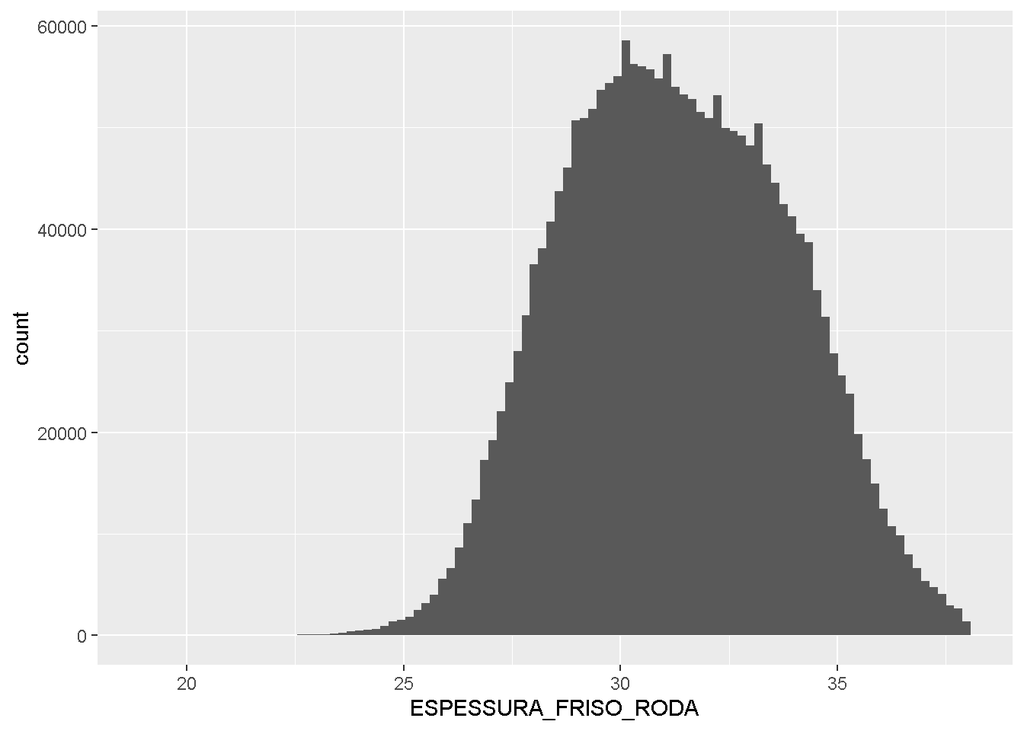

```r
c1 <- ggplot(data=waysides_r, aes(x= ESPESSURA_FRISO_RODA))
c1 + geom_histogram(bins = 100) + xlab("ESPESSURA_FRISO_RODA")
```

Histograma da variável CAVA_RODA

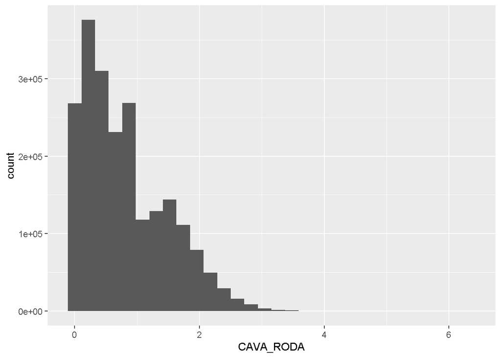

```r
c2 <- ggplot(data=waysides_r, aes(x= CAVA_RODA))
c2 + geom_histogram(bins=30) + xlab("CAVA_RODA")
```

Histograma da variável ALINHAMENTO_ENTRE_EIXOS

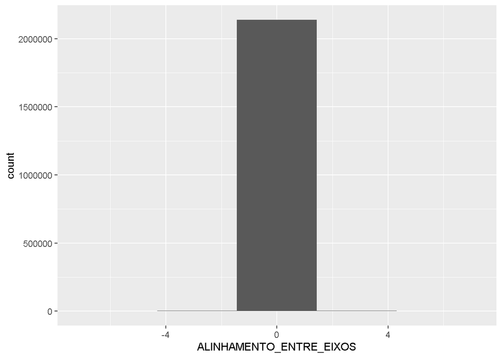

```r
c3 <- ggplot(data=waysides_r, aes(x= ALINHAMENTO_ENTRE_EIXOS))
c3 + geom_histogram(bins=5) + xlab("ALINHAMENTO_ENTRE_EIXOS")
```

Histograma da variável ALTURA_FRISO_RODA

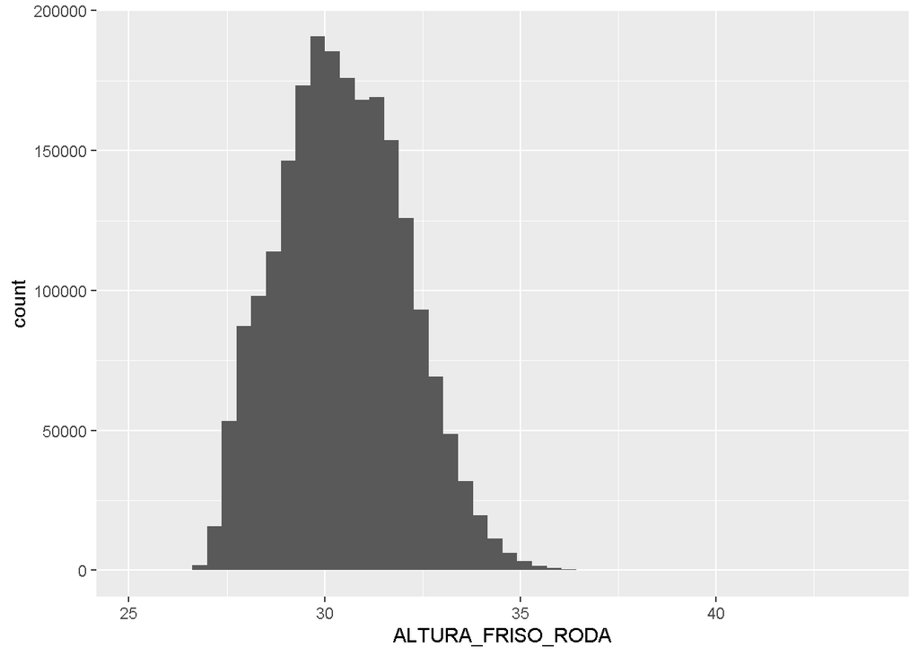

```r
c4 <- ggplot(data=waysides_r, aes(x= ALTURA_FRISO_RODA))
c4 + geom_histogram(bins=50) + xlab("ALTURA_FRISO_RODA")
```

Histograma da variável ANGULO_FRISO_RODA

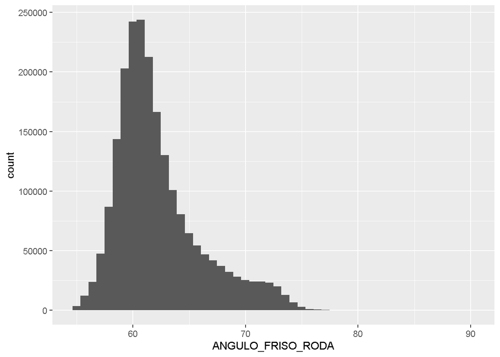

```r
c5 <- ggplot(data=waysides_r, aes(x= ANGULO_FRISO_RODA))
c5 + geom_histogram(bins=50) + xlab("ANGULO_FRISO_RODA")
```

Histograma da variável ANGULO_ATAQUE_EIXO_FRONTAL_TRUQUE

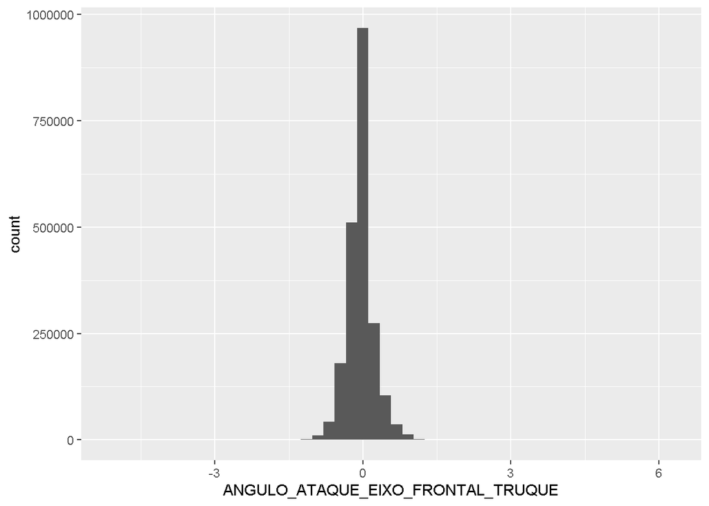

```r
c6 <- ggplot(data=waysides_r, aes(x= ANGULO_ATAQUE_EIXO_FRONTAL_TRUQUE))
c6 + geom_histogram(bins=50) + xlab("ANGULO_ATAQUE_EIXO_FRONTAL_TRUQUE")
```

Histograma da variável ANGULO_ATAQUE_EIXO_TRASEIRO_TRUQUE

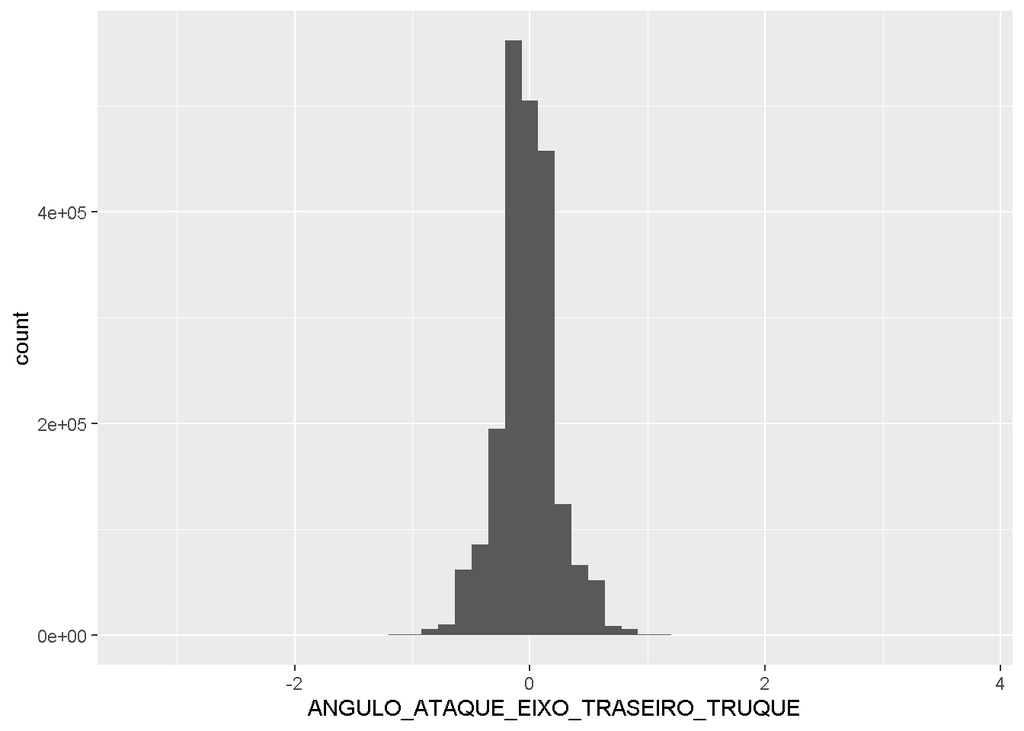

```r
c7 <- ggplot(data=waysides_r, aes(x= ANGULO_ATAQUE_EIXO_TRASEIRO_TRUQUE))
c7 + geom_histogram(bins=50) + xlab("ANGULO_ATAQUE_EIXO_TRASEIRO_TRUQUE")
```

Histograma da variável TRACKING_POSITION_EIXO_TRASEIRO_TRUQUE

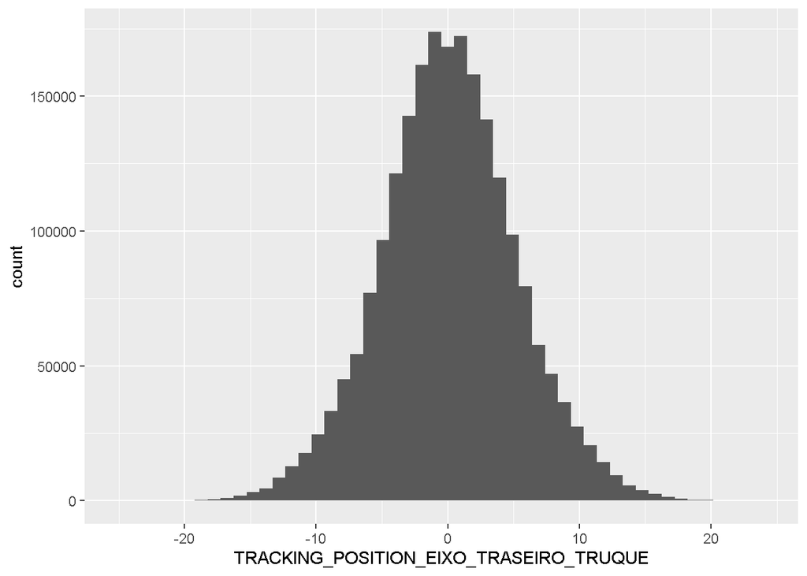

```r
c8 <- ggplot(data=waysides_r, aes(x= TRACKING_POSITION_EIXO_TRASEIRO_TRUQUE))
c8 + geom_histogram(bins=50) + xlab("TRACKING_POSITION_EIXO_TRASEIRO_TRUQUE")
```

Histograma da variável TRACKING_POSITION_EIXO_FRONTAL_TRUQUE

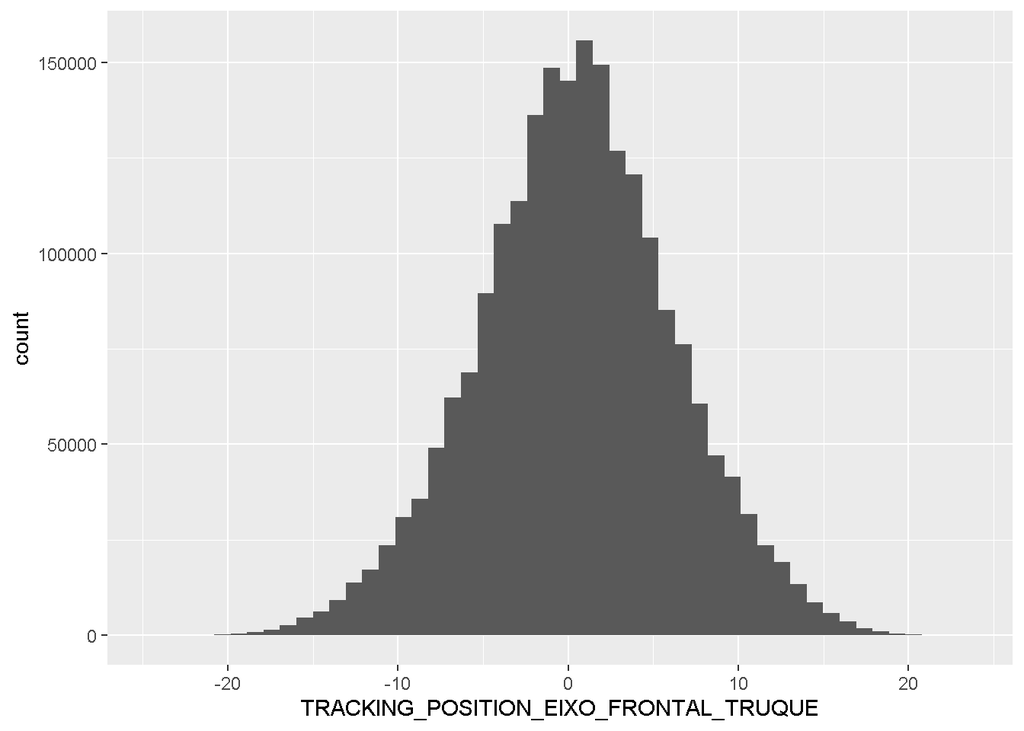

```r
c9 <- ggplot(data=waysides_r, aes(x= TRACKING_POSITION_EIXO_FRONTAL_TRUQUE))
c9 + geom_histogram(bins =50) + xlab("TRACKING_POSITION_EIXO_FRONTAL_TRUQUE")
```

Histograma da variável ROTACAO_EIXO

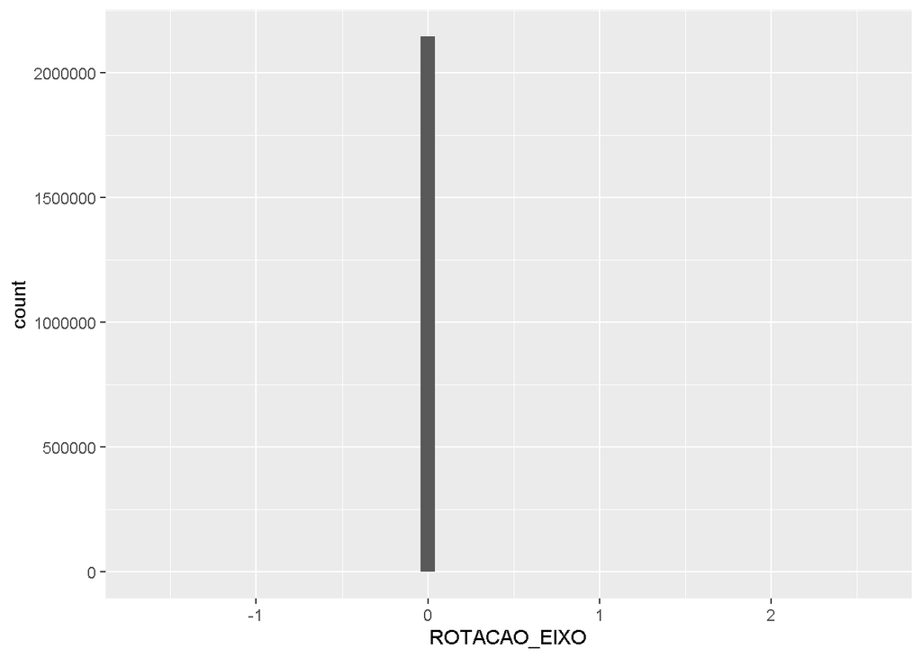

```r
c10 <- ggplot(data=waysides_r, aes(x= ROTACAO_EIXO))
c10 + geom_histogram(bins=50) + xlab("ROTACAO_EIXO")
```

Histograma da variável DESLOCAMENTO_ENTRE_EIXOS

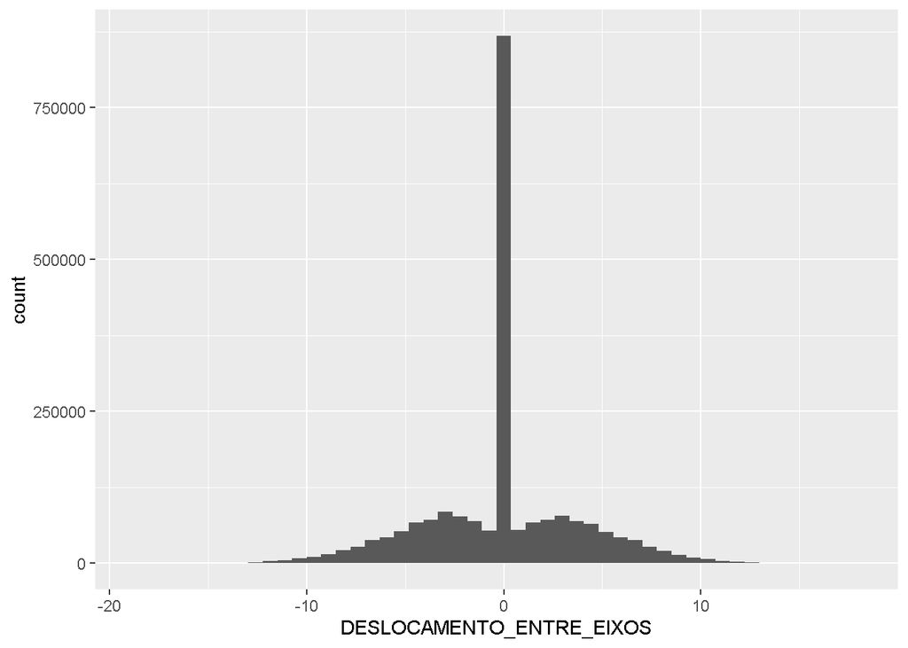

```r
c11 <- ggplot(data=waysides_r, aes(x= DESLOCAMENTO_ENTRE_EIXOS))
c11 + geom_histogram(bins=50) + xlab("DESLOCAMENTO_ENTRE_EIXOS")
```

Histograma da variável TRACKING_ERROR

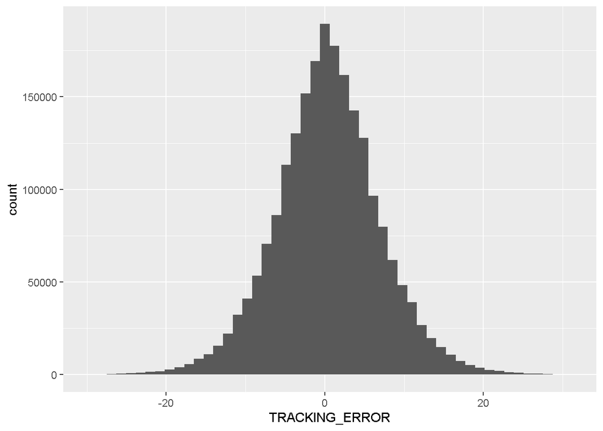

```r
c12 <- ggplot(data=waysides_r, aes(x= TRACKING_ERROR))
c12 + geom_histogram(bins=50) + xlab("TRACKING_ERROR")
```

Histograma da variável VELOCIDADE_SAIDA_TREM

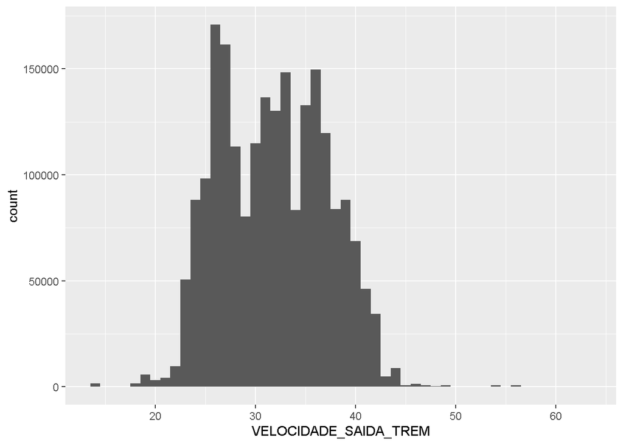

```r
waysides_r$VELOCIDADE_SAIDA_TREM <- as.numeric(waysides_r$VELOCIDADE_SAIDA_TREM)
c13 <- ggplot(data=waysides_r, aes(x= VELOCIDADE_SAIDA_TREM))
c13 + geom_histogram(bins=50) + xlab("VELOCIDADE_SAIDA_TREM")
```

#### Transformamos a variável ESPESSURA_FRISO_RODA em “Yes”, “No”.

A espessura está abaixo de 26mm: “yes” tem que trocar a roda. A espessura não está abaixo de 26mm: “não”, não precisa trocar a roda.

```r
waysides_r$trocar <- SparkR::ifelse(waysides_r$ESPESSURA_FRISO_RODA < 26, "Yes", "No")
summary(waysides_r)
```

```
##      ROW_ID           DATA_HORA_LEITURA              CODIGO_VAGAO
##  Min.   :-2.147e+09   Min.   :2016-09-09 19:26:33   Min.   :   171
##  1st Qu.:-1.073e+09   1st Qu.:2018-07-04 05:05:04   1st Qu.:502191
##  Median : 1.066e+06   Median :2018-07-23 03:54:19   Median :552147
##  Mean   : 1.164e+06   Mean   :2018-07-16 18:41:47   Mean   :506280
##  3rd Qu.: 1.075e+09   3rd Qu.:2018-08-10 01:58:25   3rd Qu.:632582
##  Max.   : 2.147e+09   Max.   :2018-08-24 19:47:11   Max.   :922106
##  CODIGO_RODEIRO    CODIGO_RODA         LADO_RODA           EIXO_VAGAO
##  Min.   :   1711   Length:2145868     Length:2145868     Min.   :1.000
##  1st Qu.:5021913   Class :character   Class :character   1st Qu.:1.000
##  Median :5521474   Mode  :character   Mode  :character   Median :3.000
##  Mean   :5062801                                         Mean   :2.489
##  3rd Qu.:6325822                                         3rd Qu.:3.000
##  Max.   :9221064                                         Max.   :4.000
##  CICLO_RODEIRO        TRAIN_ID         SENTIDO_TREM
##  Length:2145868     Length:2145868     Length:2145868
##  Class :character   Class :character   Class :character
##  Mode  :character   Mode  :character   Mode  :character
##
##
##
##  VELOCIDADE_ENTRADA_TREM VELOCIDADE_SAIDA_TREM POSICAO_VAGAO_COMPOSICAO
##  Min.   :15.0            Min.   :14.0          Min.   :  1.0
##  1st Qu.:39.0            1st Qu.:27.0          1st Qu.: 80.0
##  Median :48.0            Median :32.0          Median :163.0
##  Mean   :46.2            Mean   :31.8          Mean   :163.2
##  3rd Qu.:53.0            3rd Qu.:36.0          3rd Qu.:245.0
##  Max.   :66.0            Max.   :63.0          Max.   :334.0
##  ANGULO_FRISO_RODA ALTURA_FRISO_RODA ESPESSURA_FRISO_RODA   CAVA_RODA
##  Min.   :55.00     Min.   :25.30     Min.   :19.01        Min.   :0.0000
##  1st Qu.:59.67     1st Qu.:29.31     1st Qu.:29.34        1st Qu.:0.2500
##  Median :61.26     Median :30.41     Median :31.20        Median :0.6700
##  Mean   :62.24     Mean   :30.47     Mean   :31.28        Mean   :0.8111
##  3rd Qu.:63.84     3rd Qu.:31.59     3rd Qu.:33.20        3rd Qu.:1.2700
##  Max.   :89.99     Max.   :43.80     Max.   :38.00        Max.   :6.3100
##  ANGULO_ATAQUE_EIXO_FRONTAL_TRUQUE ANGULO_ATAQUE_EIXO_TRASEIRO_TRUQUE
##  Min.   :-5.10000                  Min.   :-3.3000
##  1st Qu.:-0.20000                  1st Qu.:-0.2000
##  Median :-0.06667                  Median : 0.0000
##  Mean   :-0.04408                  Mean   :-0.0238
```

[output cut: 8 more lines]

```
##  Max.   : 23.5000                      Max.   : 23.60000
##   ROTACAO_EIXO        ALINHAMENTO_ENTRE_EIXOS DESLOCAMENTO_ENTRE_EIXOS
##  Min.   :-1.6333333   Min.   :-5.50000        Min.   :-18.767
##  1st Qu.: 0.0000000   1st Qu.:-0.20000        1st Qu.: -1.800
##  Median : 0.0000000   Median : 0.00000        Median :  0.000
##  Mean   : 0.0001341   Mean   :-0.02028        Mean   : -0.056
##  3rd Qu.: 0.0000000   3rd Qu.: 0.20000        3rd Qu.:  1.500
##  Max.   : 2.5500002   Max.   : 6.00000        Max.   : 17.500
##  TRACKING_ERROR     SERPENTEAMENTO    trocar
##  Min.   :-29.9000   Min.   :0      Length:2145868
##  1st Qu.: -3.6333   1st Qu.:0      Class :character
##  Median :  0.4000   Median :0      Mode  :character
##  Mean   :  0.3826   Mean   :0
##  3rd Qu.:  4.4000   3rd Qu.:0
##  Max.   : 30.0000   Max.   :0
```

#### Gráficos boxplots para representar as variáveis em função da quantidade de “Yes” e “No”.

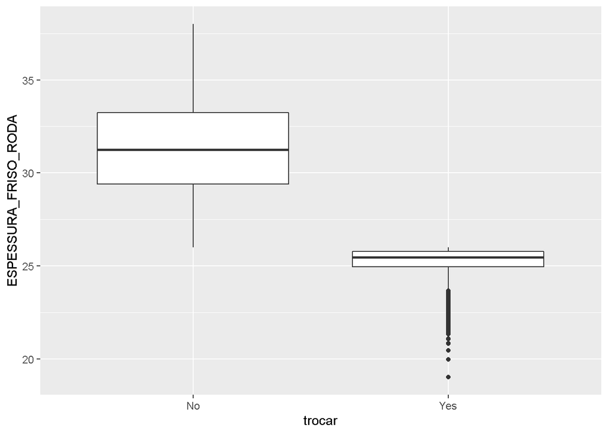

```r
b1 <- ggplot(data=waysides_r, aes(x= as.factor(trocar), y=ESPESSURA_FRISO_RODA))
b1 + geom_boxplot() + xlab("trocar")
```

#### Plot correlações entre variáveis

```r
d <- waysides_r[,c(11,12,14:25)]
str(waysides_r)
```

```
## tibble [2,145,868 x 27] (S3: spec_tbl_df/tbl_df/tbl/data.frame)
##  $ ROW_ID                                : num [1:2145868] -9.13e+08 8.15e+07 1.70e+09 -8.19e+08 -1.58e+09 ...
##  $ DATA_HORA_LEITURA                     : POSIXct[1:2145868], format: "2018-06-23 03:48:57" "2018-05-30 22:42:52" ...
##  $ CODIGO_VAGAO                          : num [1:2145868] 620355 612379 67664 637568 917561 ...
##  $ CODIGO_RODEIRO                        : num [1:2145868] 6203551 6123794 676642 6375684 9175613 ...
##  $ CODIGO_RODA                           : chr [1:2145868] "6203551RIGHT" "6123794RIGHT" "0676642LEFT" "6375684LEFT" ...
##  $ LADO_RODA                             : chr [1:2145868] "RIGHT" "RIGHT" "LEFT" "LEFT" ...
##  $ EIXO_VAGAO                            : num [1:2145868] 1 4 2 4 3 4 1 3 2 2 ...
##  $ CICLO_RODEIRO                         : chr [1:2145868] "6203551RIGHT" "6123794RIGHT" "0676642LEFT" "6375684LEFT" ...
##  $ TRAIN_ID                              : chr [1:2145868] "15B2DC329" "15B0F28EC" "25B382FE1" "25B54D39F" ...
##  $ SENTIDO_TREM                          : chr [1:2145868] "SLZ" "SLZ" "SLZ" "SLZ" ...
##  $ VELOCIDADE_ENTRADA_TREM               : num [1:2145868] 35 58 52 52 52 43 36 52 48 54 ...
##  $ VELOCIDADE_SAIDA_TREM                 : num [1:2145868] 24 41 35 35 33 29 25 34 32 36 ...
##  $ POSICAO_VAGAO_COMPOSICAO              : num [1:2145868] 161 59 108 66 192 35 218 13 115 211 ...
##  $ ANGULO_FRISO_RODA                     : num [1:2145868] 62.5 63.8 66.6 61.9 59.5 ...
##  $ ALTURA_FRISO_RODA                     : num [1:2145868] 28.8 30.4 30 31.1 30.7 ...
##  $ ESPESSURA_FRISO_RODA                  : num [1:2145868] 29.4 31.2 31.8 33.5 34.1 ...
##  $ CAVA_RODA                             : num [1:2145868] 0.23 0.28 0.26 0.05 1.09 ...
##  $ ANGULO_ATAQUE_EIXO_FRONTAL_TRUQUE     : num [1:2145868] -0.167 0.2 -0.7 0 -0.4 ...
##  $ ANGULO_ATAQUE_EIXO_TRASEIRO_TRUQUE    : num [1:2145868] 0.267 -0.5 0.2 0.2 -0.3 ...
##  $ TRACKING_POSITION_EIXO_FRONTAL_TRUQUE : num [1:2145868] 2.73 4.7 -3.8 -3.1 9 ...
##  $ TRACKING_POSITION_EIXO_TRASEIRO_TRUQUE: num [1:2145868] 9.53 3 -3.6 -2.9 6.2 ...
##  $ ROTACAO_EIXO                          : num [1:2145868] 0 0 0 0 0 0 0 0 0 0 ...
##  $ ALINHAMENTO_ENTRE_EIXOS               : num [1:2145868] -0.433 0.7 -0.9 -0.2 -0.1 ...
##  $ DESLOCAMENTO_ENTRE_EIXOS              : num [1:2145868] 3.73 2.3 -4 -3.3 3.1 ...
##  $ TRACKING_ERROR                        : num [1:2145868] -6.8 1.7 -0.2 -0.2 2.8 ...
##  $ SERPENTEAMENTO                        : num [1:2145868] 0 0 0 0 0 0 0 0 0 0 ...
##  $ trocar                                : chr [1:2145868] "No" "No" "No" "No" ...
##  - attr(*, "problems")= tibble [2,354 x 5] (S3: tbl_df/tbl/data.frame)
##   ..$ row     : int [1:2354] 4240 9225 11878 12771 13340 13592 13652 13712 13941 14001 ...
##   ..$ col     : chr [1:2354] "ALTURA_FRISO_RODA" "ALTURA_FRISO_RODA" "ALTURA_FRISO_RODA" "ALTURA_FRISO_RODA" ...
##   ..$ expected: chr [1:2354] "a double" "a double" "a double" "a double" ...
##   ..$ actual  : chr [1:2354] "NULL" "NULL" "NULL" "NULL" ...
##   ..$ file    : chr [1:2354] "'C:/Users/Pichau/Documents/MBA/Desafios e Requisitos Analiticos/EFC_WAYSIDES.csv'" "'C:/Users/Pichau/Documents/MBA/Desafios e Requisitos Analiticos/EFC_WAYSIDES.csv'" "'C:/Users/Pichau/Documents/MBA/Desafios e Requisitos Analiticos/EFC_WAYSIDES.csv'" "'C:/Users/Picha…
##  - attr(*, "spec")=
##   .. cols(
##   ..   ROW_ID = col_double(),
##   ..   DATA_HORA_LEITURA = col_datetime(format = ""),
##   ..   CODIGO_VAGAO = col_double(),
##   ..   CODIGO_RODEIRO = col_double(),
```

[output cut: 8 more lines]

```
##   ..   POSICAO_VAGAO_COMPOSICAO = col_double(),
##   ..   ANGULO_FRISO_RODA = col_character(),
##   ..   ALTURA_FRISO_RODA = col_double(),
##   ..   ESPESSURA_FRISO_RODA = col_character(),
##   ..   CAVA_RODA = col_character(),
##   ..   ANGULO_ATAQUE_EIXO_FRONTAL_TRUQUE = col_character(),
##   ..   ANGULO_ATAQUE_EIXO_TRASEIRO_TRUQUE = col_character(),
##   ..   TRACKING_POSITION_EIXO_FRONTAL_TRUQUE = col_character(),
##   ..   TRACKING_POSITION_EIXO_TRASEIRO_TRUQUE = col_character(),
##   ..   ROTACAO_EIXO = col_character(),
##   ..   `ALINHAMENTO_ENTRE_EIXOS_(IAM)` = col_character(),
##   ..   `DESLOCAMENTO_ENTRE_EIXOS_(SHIFT)` = col_character(),
##   ..   `TRACKING_ERROR_(TE)` = col_character(),
##   ..   `SERPENTEAMENTO_(HUNTING)` = col_character()
##   .. )
```

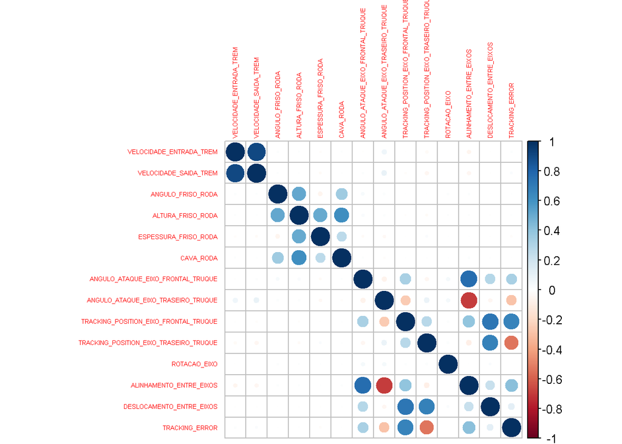

```r
correlacao <- cor(d)
corrplot(correlacao, tl.cex = 0.4)
```

#### Verificando as variáveis explicativas que apresentam autocorrelação com nível de significância superior a 65%

```r
alt_cor <- findCorrelation(correlacao, cutoff = 0.65, verbose = FALSE)
colnames(d[,alt_cor])
```

[output not shown]

#### Correlação entre as variáveis:

ALINHAMENTO_ENTRE_EIXOS e ANGULO_ATAQUE_EIXO_TRASEIRO_TRUQUE: -0.69959310

ALINHAMENTO_ENTRE_EIXOS e ANGULO_ATAQUE_EIXO_FRONTAL_TRUQUE: 0.76102122

DESLOCAMENTO_ENTRE_EIXOS e TRACKING_POSITION_EIXO_FRONTAL_TRUQUE: 0.722928341

CAVA_RODA e ALTURA_FRISO_RODA: 0.611303454

VELOCIDADE_ENTRADA_TREM e VELOCIDADE_SAIDA_TREM: 0.9053523234

Foram removidas as variáveis explicativas TRACKING_POSITION_EIXO_FRONT, DESLOCAMENTO_ENTRE_EIXOS, ALINHAMENTO_ENTRE_EIXOS e VELOCIDADE_SAIDA_TREM por apresentarem autocorrelação superior a 65%.

#### Importando a base de dados com o SparkR

```r
waysides <- read.df(df_path, header='true', source = "com.databricks.spark.csv", inferSchema='true')
```

### Analise e modelagem com SparkR

#### Transformamos as variáveis númericas que vieram como string para o tipo float

```r
waysides$ESPESSURA_FRISO_RODA <- SparkR::cast(waysides$ESPESSURA_FRISO_RODA, "float")

waysides$ANGULO_FRISO_RODA <- SparkR::cast(waysides$ANGULO_FRISO_RODA, "float")
waysides$ALTURA_FRISO_RODA <- SparkR::cast(waysides$ALTURA_FRISO_RODA, "float")
waysides$CAVA_RODA <- SparkR::cast(waysides$CAVA_RODA, "float")
waysides$ANGULO_ATAQUE_EIXO_FRONTAL_TRUQUE <- SparkR::cast(waysides$ANGULO_ATAQUE_EIXO_FRONTAL_TRUQUE, "float")
waysides$ANGULO_ATAQUE_EIXO_TRASEIRO_TRUQUE <- SparkR::cast(waysides$ANGULO_ATAQUE_EIXO_TRASEIRO_TRUQUE, "float")
waysides$TRACKING_POSITION_EIXO_FRONTAL_TRUQUE <- SparkR::cast(waysides$TRACKING_POSITION_EIXO_FRONTAL_TRUQUE, "float")
waysides$TRACKING_POSITION_EIXO_TRASEIRO_TRUQUE  <- SparkR::cast(waysides$TRACKING_POSITION_EIXO_TRASEIRO_TRUQUE, "float")
waysides$ROTACAO_EIXO <- SparkR::cast(waysides$ROTACAO_EIXO, "float")
```

A Variável SERPENTEAMENTO não será utilizada por apresentar somente valores nulos, iguais a zero, e valores ausentes (NAs)

#### Checando os tipos das variáveis

```r
printSchema(waysides)
```

```
## root
##  |-- ROW_ID: integer (nullable = true)
##  |-- DATA_HORA_LEITURA: string (nullable = true)
##  |-- CODIGO_VAGAO: integer (nullable = true)
##  |-- CODIGO_RODEIRO: integer (nullable = true)
##  |-- CODIGO_RODA: string (nullable = true)
##  |-- LADO_RODA: string (nullable = true)
##  |-- EIXO_VAGAO: integer (nullable = true)
##  |-- CICLO_RODEIRO: string (nullable = true)
##  |-- TRAIN_ID: string (nullable = true)
##  |-- SENTIDO_TREM: string (nullable = true)
##  |-- VELOCIDADE_ENTRADA_TREM: integer (nullable = true)
##  |-- VELOCIDADE_SAIDA_TREM: integer (nullable = true)
##  |-- POSICAO_VAGAO_COMPOSICAO: integer (nullable = true)
##  |-- ANGULO_FRISO_RODA: float (nullable = true)
##  |-- ALTURA_FRISO_RODA: float (nullable = true)
##  |-- ESPESSURA_FRISO_RODA: float (nullable = true)
##  |-- CAVA_RODA: float (nullable = true)
##  |-- ANGULO_ATAQUE_EIXO_FRONTAL_TRUQUE: float (nullable = true)
##  |-- ANGULO_ATAQUE_EIXO_TRASEIRO_TRUQUE: float (nullable = true)
##  |-- TRACKING_POSITION_EIXO_FRONTAL_TRUQUE: float (nullable = true)
##  |-- TRACKING_POSITION_EIXO_TRASEIRO_TRUQUE: float (nullable = true)
##  |-- ROTACAO_EIXO: float (nullable = true)
##  |-- ALINHAMENTO_ENTRE_EIXOS_(IAM): string (nullable = true)
##  |-- DESLOCAMENTO_ENTRE_EIXOS_(SHIFT): string (nullable = true)
##  |-- TRACKING_ERROR_(TE): string (nullable = true)
##  |-- SERPENTEAMENTO_(HUNTING): string (nullable = true)
```

#### Renomeamos as variáveis abaixo para facilitar o seu uso nos códigos e transformamos para o tipo float

```r
waysides$ALINHAMENTO_ENTRE_EIXOS <- SparkR::cast(waysides$`ALINHAMENTO_ENTRE_EIXOS_(IAM)`, "float")
waysides$`ALINHAMENTO_ENTRE_EIXOS_(IAM)` <- NULL
```

```r
waysides$DESLOCAMENTO_ENTRE_EIXOS <- SparkR::cast(waysides$`DESLOCAMENTO_ENTRE_EIXOS_(SHIFT)`, "float")
waysides$`DESLOCAMENTO_ENTRE_EIXOS_(SHIFT)` <- NULL
```

```r
waysides$TRACKING_ERROR <- SparkR::cast(waysides$`TRACKING_ERROR_(TE)`, "float")
waysides$`TRACKING_ERROR_(TE)` <- NULL
```

```r
waysides$SERPENTEAMENTO <- SparkR::cast(waysides$`SERPENTEAMENTO_(HUNTING)`, "float")
waysides$`SERPENTEAMENTO_(HUNTING)` <- NULL
```

#### Criamos duas variaveis target chamadas de trocar (tipo string) e trocar2 (tipo double) para quando a ESPESSURA_FRISO_RODA estiver abaixo de 26cm

```r
waysides$trocar <- SparkR::ifelse(waysides$ESPESSURA_FRISO_RODA < 26, "Yes", "No") # do tipo string
waysides$trocar2 <- SparkR::ifelse(waysides$ESPESSURA_FRISO_RODA < 26, 1, 0) # do tipo double
```

#### Removemos os valores faltantes de todas as colunas

```r
# Removendo NA's da variavel CICLO_RODEIRO
#filter(waysides, isNull(waysides$CICLO_RODEIRO)) %>% count()
waysides <- filter(waysides, isNotNull(waysides$CICLO_RODEIRO))

# Removendo NA's da variavel CODIGO_RODA
#filter(waysides, isNull(waysides$CODIGO_RODA)) %>% count()
waysides <- filter(waysides, isNotNull(waysides$CODIGO_RODA))

# Removendo NA's da variavel ANGULO_FRISO_RODA
# filter(waysides, isNull(waysides$ANGULO_FRISO_RODA)) %>% count()
waysides <- filter(waysides, isNotNull(waysides$ANGULO_FRISO_RODA))

# Removendo NA's da variavel ALTURA_FRISO_RODA
# filter(waysides, isNull(waysides$ALTURA_FRISO_RODA)) %>% count()
waysides <- filter(waysides, isNotNull(waysides$ALTURA_FRISO_RODA))

# Removendo NA's da variavel ESPESSURA_FRISO_RODA
# filter(waysides, isNull(waysides$ESPESSURA_FRISO_RODA)) %>% count()
waysides <- filter(waysides, isNotNull(waysides$ESPESSURA_FRISO_RODA))

# Removendo NA's da variavel CAVA_RODA
#filter(waysides, isNull(waysides$CAVA_RODA)) %>% count()
waysides <- filter(waysides, isNotNull(waysides$CAVA_RODA))

# Removendo NA's da variavel ANGULO_ATAQUE_EIXO_FRONTAL_TRUQUE
#filter(waysides, isNull(waysides$ANGULO_ATAQUE_EIXO_FRONTAL_TRUQUE)) %>% count()
waysides <- filter(waysides, isNotNull(waysides$ANGULO_ATAQUE_EIXO_FRONTAL_TRUQUE))

# Removendo NA's da variavel ANGULO_ATAQUE_EIXO_TRASEIRO_TRUQUE
#filter(waysides, isNull(waysides$ANGULO_ATAQUE_EIXO_TRASEIRO_TRUQUE)) %>% count()
waysides <- filter(waysides, isNotNull(waysides$ANGULO_ATAQUE_EIXO_TRASEIRO_TRUQUE))

# Removendo NA's da variavel TRACKING_POSITION_EIXO_FRONTAL_TRUQUE
#filter(waysides, isNull(waysides$TRACKING_POSITION_EIXO_FRONTAL_TRUQUE)) %>% count()
waysides <- filter(waysides, isNotNull(waysides$TRACKING_POSITION_EIXO_FRONTAL_TRUQUE))

# Removendo NA's da variavel TRACKING_POSITION_EIXO_TRASEIRO_TRUQUE
#filter(waysides, isNull(waysides$TRACKING_POSITION_EIXO_TRASEIRO_TRUQUE)) %>% count()
waysides <- filter(waysides, isNotNull(waysides$TRACKING_POSITION_EIXO_TRASEIRO_TRUQUE))

# Removendo NA's da variavel ROTACAO_EIXO
#filter(waysides, isNull(waysides$ROTACAO_EIXO)) %>% count()
waysides <- filter(waysides, isNotNull(waysides$ROTACAO_EIXO))

# Removendo NA's da variavel ALINHAMENTO_ENTRE_EIXOS
#filter(waysides, isNull(waysides$ALINHAMENTO_ENTRE_EIXOS)) %>% count() #19.731 NA's
waysides <- filter(waysides, isNotNull(waysides$ALINHAMENTO_ENTRE_EIXOS))

# Removendo NA's da variavel DESLOCAMENTO_ENTRE_EIXOS
#filter(waysides, isNull(waysides$DESLOCAMENTO_ENTRE_EIXOS)) %>% count()
waysides <- filter(waysides, isNotNull(waysides$DESLOCAMENTO_ENTRE_EIXOS))

# Removendo NA's da variavel TRACKING_ERROR
#filter(waysides, isNull(waysides$TRACKING_ERROR)) %>% count()
waysides <- filter(waysides, isNotNull(waysides$TRACKING_ERROR))

# Removendo NA's da variavel SERPENTEAMENTO
#filter(waysides, isNull(waysides$SERPENTEAMENTO)) %>% count()
waysides <- filter(waysides, isNotNull(waysides$SERPENTEAMENTO))
```

#### Número de observações em que a variável CODIGO_RODA é diferente da variável CICLO_RODEIRO

```r
filter(waysides, waysides$CODIGO_RODA != waysides$CICLO_RODEIRO) %>% count()
```

```
## [1] 11350
```

#### Excluimos as observações em que CODIGO_RODA é diferente de CICLO_RODEIRO

Não faz sentido fazer as predições de desgaste da roda para os rodeiros com início de ciclo até porque eles acabaram de ser trocados e não terão espessura menor que 26mm na próxima leitura.

```r
waysides <- filter(waysides, waysides$CODIGO_RODA == waysides$CICLO_RODEIRO)
```

#### Count de “0” (não trocar) e “1” (trocar) da variável trocar2

```r
zb_f <- count(groupBy(waysides, "trocar2"))
showDF(zb_f)
```

```
## +-------+-------+
## |trocar2|  count|
## +-------+-------+
## |    0.0|2111134|
## |    1.0|  23384|
## +-------+-------+
```

A base possui forte desbalanceamento, por isso criamos pesos para penalizar a classe majoritária e valorizar a classe minoritária

#### Criando pesos para cada classe (“Yes” e “No”)

```r
#peso 2
# wj=n_samples / (n_classes * n_samplesj)
n_samples <- 2121955+23913
n_classes <- 2
n_samples_yes <- 23913
n_samples_no <- 2121955

# pesos 2
w_yes <- n_samples / (n_classes * n_samples_yes)
w_no <- n_samples / (n_classes * n_samples_no)

# criando nova coluna weights2
waysides$weights2 <- ifelse(waysides$trocar == "No",
                            w_no,
                            w_yes)
```

#### Verificando a distribuição dos pesos para cada classe

```r
zb_f <- count(groupBy(waysides, "weights2"))
showDF(zb_f)
```

```
## +------------------+-------+
## |          weights2|  count|
## +------------------+-------+
## | 44.86823066951031|  23384|
## |0.5056346623750269|2111134|
## +------------------+-------+
```

#### Separação da base em treino e teste

```r
split <- randomSplit(waysides, c(7, 3), 2)
train <- split[[1]]
test <- split[[2]]
```

#### Verificando o desbalanceamento da base de treino

```r
zb_f <- count(groupBy(train, "trocar2"))
showDF(zb_f)
```

```
## +-------+-------+
## |trocar2|  count|
## +-------+-------+
## |    0.0|1477462|
## |    1.0|  16430|
## +-------+-------+
```

#### Verificando o desbalanceamento da base de teste

```r
zb_f <- count(groupBy(test, "trocar2"))
showDF(zb_f)
```

```
## +-------+------+
## |trocar2| count|
## +-------+------+
## |    0.0|633672|
## |    1.0|  6954|
## +-------+------+
```

## Regressão Logística

Modelo com thresholds 0.5, com pesos e elasticNetParam = 1

```r
model_logit_w_elasticNetParam1_t5 <- spark.logit(train, trocar2 ~ ANGULO_FRISO_RODA + VELOCIDADE_ENTRADA_TREM + ALTURA_FRISO_RODA + CAVA_RODA + ANGULO_ATAQUE_EIXO_TRASEIRO_TRUQUE + TRACKING_POSITION_EIXO_TRASEIRO_TRUQUE + ROTACAO_EIXO + TRACKING_ERROR,
                                      elasticNetParam = 1, weightCol = "weights2", thresholds = 0.5)
```

Modelo com thresholds 0.6, com pesos e elasticNetParam = 1

```r
model_logit_w_elasticNetParam1_t6 <- spark.logit(train, trocar2 ~ ANGULO_FRISO_RODA + VELOCIDADE_ENTRADA_TREM + ALTURA_FRISO_RODA + CAVA_RODA + ANGULO_ATAQUE_EIXO_TRASEIRO_TRUQUE + TRACKING_POSITION_EIXO_TRASEIRO_TRUQUE + ROTACAO_EIXO + TRACKING_ERROR,
                                       elasticNetParam = 1, weightCol = "weights2", thresholds = 0.6)
```

Modelo com thresholds 0.7, com pesos e elasticNetParam = 1

```r
model_logit_w_elasticNetParam1_t7 <- spark.logit(train, trocar2 ~ ANGULO_FRISO_RODA + VELOCIDADE_ENTRADA_TREM + ALTURA_FRISO_RODA + CAVA_RODA + ANGULO_ATAQUE_EIXO_TRASEIRO_TRUQUE + TRACKING_POSITION_EIXO_TRASEIRO_TRUQUE + ROTACAO_EIXO + TRACKING_ERROR,
                                       elasticNetParam = 1, weightCol = "weights2", thresholds = 0.7)
```

#### Obtendo os coeficientes das variáveis para cada modelo

```r
summary_w_elasticNetParam1_t5 <- summary(model_logit_w_elasticNetParam1_t5)
summary_w_elasticNetParam1_t5
```

```
## $coefficients
##                                           Estimate
## (Intercept)                             2.28640105
## ANGULO_FRISO_RODA                       0.28935885
## VELOCIDADE_ENTRADA_TREM                 0.01277084
## ALTURA_FRISO_RODA                      -0.73538897
## CAVA_RODA                               0.95194404
## ANGULO_ATAQUE_EIXO_TRASEIRO_TRUQUE      0.39966827
## TRACKING_POSITION_EIXO_TRASEIRO_TRUQUE  0.01453617
## ROTACAO_EIXO                           -0.95161424
## TRACKING_ERROR                          0.02444481
```

```r
summary_w_elasticNetParam1_t6 <- summary(model_logit_w_elasticNetParam1_t6)
summary_w_elasticNetParam1_t6
```

```
## $coefficients
##                                           Estimate
## (Intercept)                             2.28640105
## ANGULO_FRISO_RODA                       0.28935885
## VELOCIDADE_ENTRADA_TREM                 0.01277084
## ALTURA_FRISO_RODA                      -0.73538897
## CAVA_RODA                               0.95194404
## ANGULO_ATAQUE_EIXO_TRASEIRO_TRUQUE      0.39966827
## TRACKING_POSITION_EIXO_TRASEIRO_TRUQUE  0.01453617
## ROTACAO_EIXO                           -0.95161424
## TRACKING_ERROR                          0.02444481
```

```r
summary_w_elasticNetParam1_t7 <- summary(model_logit_w_elasticNetParam1_t7)
summary_w_elasticNetParam1_t7
```

```
## $coefficients
##                                           Estimate
## (Intercept)                             2.28640105
## ANGULO_FRISO_RODA                       0.28935885
## VELOCIDADE_ENTRADA_TREM                 0.01277084
## ALTURA_FRISO_RODA                      -0.73538897
## CAVA_RODA                               0.95194404
## ANGULO_ATAQUE_EIXO_TRASEIRO_TRUQUE      0.39966827
## TRACKING_POSITION_EIXO_TRASEIRO_TRUQUE  0.01453617
## ROTACAO_EIXO                           -0.95161424
## TRACKING_ERROR                          0.02444481
```

#### Fazendo a predição na base de teste

```r
fitted_w_elasticNetParam1_t5 <- SparkR::predict(model_logit_w_elasticNetParam1_t5, test)

fitted_w_elasticNetParam1_t6 <- SparkR::predict(model_logit_w_elasticNetParam1_t6, test)

fitted_w_elasticNetParam1_t7 <- SparkR::predict(model_logit_w_elasticNetParam1_t7, test)
```

#### Transformando a variavel prediction para double

```r
fitted_w_elasticNetParam1_t5$prediction <- SparkR::cast(fitted_w_elasticNetParam1_t5$prediction, "double")
fitted_w_elasticNetParam1_t6$prediction <- SparkR::cast(fitted_w_elasticNetParam1_t6$prediction, "double")
fitted_w_elasticNetParam1_t7$prediction <- SparkR::cast(fitted_w_elasticNetParam1_t7$prediction, "double")
```

### Avaliação dos modelos pela acurácia, precisão, sensibilidade e f1.score

```r
SparkR::createOrReplaceTempView(fitted_w_elasticNetParam1_t5, "predictions1")
VP_1 <- SparkR::sql("SELECT prediction, trocar2 FROM predictions1 WHERE prediction = 1 AND trocar2 = 1")
FP_1 <- SparkR::sql("SELECT prediction, trocar2 FROM predictions1 WHERE prediction = 1 AND trocar2 = 0")
VN_1 <- SparkR::sql("SELECT prediction, trocar2 FROM predictions1 WHERE prediction = 0 AND trocar2 = 0")
FN_1 <- SparkR::sql("SELECT prediction, trocar2 FROM predictions1 WHERE prediction = 0 AND trocar2 = 1")

VP_c_1 <- SparkR::count(VP_1)
FP_c_1 <- SparkR::count(FP_1)
VN_c_1 <- SparkR::count(VN_1)
FN_c_1 <- SparkR::count(FN_1)

SparkR::createOrReplaceTempView(fitted_w_elasticNetParam1_t6, "predictions2")
VP_2 <- SparkR::sql("SELECT prediction, trocar2 FROM predictions2 WHERE prediction = 1 AND trocar2 = 1")
FP_2 <- SparkR::sql("SELECT prediction, trocar2 FROM predictions2 WHERE prediction = 1 AND trocar2 = 0")
VN_2 <- SparkR::sql("SELECT prediction, trocar2 FROM predictions2 WHERE prediction = 0 AND trocar2 = 0")
FN_2 <- SparkR::sql("SELECT prediction, trocar2 FROM predictions2 WHERE prediction = 0 AND trocar2 = 1")

VP_c_2 <- SparkR::count(VP_2)
FP_c_2 <- SparkR::count(FP_2)
VN_c_2 <- SparkR::count(VN_2)
FN_c_2 <- SparkR::count(FN_2)

SparkR::createOrReplaceTempView(fitted_w_elasticNetParam1_t7, "predictions3")
VP_3 <- SparkR::sql("SELECT prediction, trocar2 FROM predictions3 WHERE prediction = 1 AND trocar2 = 1")
FP_3 <- SparkR::sql("SELECT prediction, trocar2 FROM predictions3 WHERE prediction = 1 AND trocar2 = 0")
VN_3 <- SparkR::sql("SELECT prediction, trocar2 FROM predictions3 WHERE prediction = 0 AND trocar2 = 0")
FN_3 <- SparkR::sql("SELECT prediction, trocar2 FROM predictions3 WHERE prediction = 0 AND trocar2 = 1")

VP_c_3 <- SparkR::count(VP_3)
FP_c_3 <- SparkR::count(FP_3)
VN_c_3 <- SparkR::count(VN_3)
FN_c_3 <- SparkR::count(FN_3)
```

#### Comparação das métricas de avaliação dos modelos

```r
acuracia1 <- (VP_c_1 + VN_c_1) / (VP_c_1 + VN_c_1 + FP_c_1 + FN_c_1)
acuracia1
```

```
## [1] 0.7896183
```

```r
acuracia2 <- (VP_c_2 + VN_c_2) / (VP_c_2 + VN_c_2 + FP_c_2 + FN_c_2)
acuracia2
```

```
## [1] 0.8606769
```

```r
acuracia3 <- (VP_c_3 + VN_c_3) / (VP_c_3 + VN_c_3 + FP_c_3 + FN_c_3)
acuracia3
```

```
## [1] 0.9100645
```

```r
precisao1 <- VP_c_1 / (VP_c_1 + FP_c_1)
precisao1
```

```
## [1] 0.03722557
```

```r
precisao2 <- VP_c_2 / (VP_c_2 + FP_c_2)
precisao2
```

```
## [1] 0.04810015
```

```r
precisao3 <- VP_c_3 / (VP_c_3 + FP_c_3)
precisao3
```

```
## [1] 0.05990583
```

Os modelos 1 e 2 possuem os maiores niveis de sensibilidade. Levando em conta que quanto maior a sensibilidade, maior o numero de Falso Positivos. Logo, menor a precisão do modelo, o que aumentaria os custos com manutenção. No caso de que os custos de manutenção das rodas do trem não sejam muito elevados, seria aceitável escolher o modelo mais sensível, para que o risco de parada da operação seja reduzido. Portanto, o modelo escolhido neste caso será o modelo 1, que possui sensibilidade de 73,92%.

```r
revocacao1 <- VP_c_1 / (VP_c_1 + FN_c_1)
revocacao1
```

```
## [1] 0.7392867
```

```r
revocacao2 <- VP_c_2 / (VP_c_2 + FN_c_2)
revocacao2
```

```
## [1] 0.6298533
```

```r
revocacao3 <- VP_c_3 / (VP_c_3 + FN_c_3)
revocacao3
```

```
## [1] 0.4958297
```

```r
f1 <- (2 * (precisao1 * revocacao1)) / (precisao1 + revocacao1)
f1
```

```
## [1] 0.07088199
```

```r
f2 <- (2 * (precisao2 * revocacao2)) / (precisao2 + revocacao2)
f2
```

```
## [1] 0.08937499
```

```r
f3 <- (2 * (precisao3 * revocacao3)) / (precisao3 + revocacao3)
f3
```

```
## [1] 0.1068965
```

#### Acurácia:

Modelo 1: 78.96%

Modelo 2: 86.06%

Modelo 3: 91.00%

#### Precisão:

Modelo 1: 3.72%

Modelo 2: 4.81%

Modelo 3: 5.99%

#### Sensibilidade:

Modelo 1: 73.92%

Modelo 2: 62.98%

Modelo 3: 49.58%

#### F1.score:

Modelo 1: 7.08%

Modelo 2: 8.93%

**O modelo escolhido para a Regressão Logística foi o modelo 1:**

model_logit_w_elasticNetParam1_t5 <- spark.logit(train, trocar2 ~ ANGULO_FRISO_RODA + VELOCIDADE_ENTRADA_TREM + ALTURA_FRISO_RODA + CAVA_RODA + ANGULO_ATAQUE_EIXO_TRASEIRO_TRUQUE + TRACKING_POSITION_EIXO_TRASEIRO_TRUQUE + ROTACAO_EIXO + TRACKING_ERROR, elasticNetParam = 1, weightCol = “weights2”, thresholds = 0.5)

#### Métricas de Avaliação do modelo escolhido (modelo 1):

Acurácia: 78.96%

Precisão: 3.72%

Revocação/Sensibilidade: 73.92%

F1.Score (média harmônica entre precisão e sensibilidade): 7.08%

## SVM

```r
model_svm <- spark.svmLinear(train, trocar2 ~ ANGULO_FRISO_RODA + VELOCIDADE_ENTRADA_TREM + ALTURA_FRISO_RODA + CAVA_RODA +
  ANGULO_ATAQUE_EIXO_TRASEIRO_TRUQUE +
  TRACKING_POSITION_EIXO_TRASEIRO_TRUQUE + ROTACAO_EIXO + TRACKING_ERROR, regParam = 0.5,
                               weightCol = "weights2")
```

```r
model_svm2 <- spark.svmLinear(train, trocar2 ~ ANGULO_FRISO_RODA + VELOCIDADE_ENTRADA_TREM + ALTURA_FRISO_RODA + CAVA_RODA +
  ANGULO_ATAQUE_EIXO_TRASEIRO_TRUQUE +
  TRACKING_POSITION_EIXO_TRASEIRO_TRUQUE + ROTACAO_EIXO + TRACKING_ERROR, regParam = 0.1,
                               weightCol = "weights2")
```

```r
model_svm3 <- spark.svmLinear(train, trocar2 ~ ANGULO_FRISO_RODA + VELOCIDADE_ENTRADA_TREM + ALTURA_FRISO_RODA + CAVA_RODA +
  ANGULO_ATAQUE_EIXO_TRASEIRO_TRUQUE +
  TRACKING_POSITION_EIXO_TRASEIRO_TRUQUE + ROTACAO_EIXO + TRACKING_ERROR,
                               weightCol = "weights2")
```

```r
model_svm4 <- spark.svmLinear(train, trocar2 ~ ANGULO_FRISO_RODA + VELOCIDADE_ENTRADA_TREM + ALTURA_FRISO_RODA + CAVA_RODA +
  ANGULO_ATAQUE_EIXO_TRASEIRO_TRUQUE +
  TRACKING_POSITION_EIXO_TRASEIRO_TRUQUE + ROTACAO_EIXO + TRACKING_ERROR, regParam = 1,
                               weightCol = "weights2")
```

### Avaliação dos modelos pela acurácia, precisão, sensibilidade e f1.score

```r
summary <- summary(model_svm)
summary
```

```
## $coefficients
##                                             Estimate
## (Intercept)                            -4.3537085815
## ANGULO_FRISO_RODA                       0.1051243262
## VELOCIDADE_ENTRADA_TREM                 0.0091311874
## ALTURA_FRISO_RODA                      -0.1085468544
## CAVA_RODA                               0.2726574626
## ANGULO_ATAQUE_EIXO_TRASEIRO_TRUQUE      0.2150507495
## TRACKING_POSITION_EIXO_TRASEIRO_TRUQUE  0.0006132413
## ROTACAO_EIXO                           -0.1976294078
## TRACKING_ERROR                          0.0083447372
##
## $numClasses
## [1] 2
##
## $numFeatures
## [1] 8
```

```r
fitted_svm <- SparkR::predict(model_svm, test)

fitted_svm$trocar2<- SparkR::cast(fitted_svm$trocar2, "double")
fitted_svm$prediction<- SparkR::cast(fitted_svm$prediction, "double")
dtypes(fitted_svm)
```

```
## [[1]]
## [1] "ROW_ID" "int"
##
## [[2]]
## [1] "DATA_HORA_LEITURA" "string"
##
## [[3]]
## [1] "CODIGO_VAGAO" "int"
##
## [[4]]
## [1] "CODIGO_RODEIRO" "int"
##
## [[5]]
## [1] "CODIGO_RODA" "string"
##
## [[6]]
## [1] "LADO_RODA" "string"
##
## [[7]]
## [1] "EIXO_VAGAO" "int"
##
## [[8]]
## [1] "CICLO_RODEIRO" "string"
##
## [[9]]
## [1] "TRAIN_ID" "string"
##
## [[10]]
## [1] "SENTIDO_TREM" "string"
##
## [[11]]
## [1] "VELOCIDADE_ENTRADA_TREM" "int"
##
## [[12]]
## [1] "VELOCIDADE_SAIDA_TREM" "int"
##
## [[13]]
## [1] "POSICAO_VAGAO_COMPOSICAO" "int"
##
## [[14]]
```

[output cut: 39 more lines]

```
##
## [[27]]
## [1] "trocar" "string"
##
## [[28]]
## [1] "trocar2" "double"
##
## [[29]]
## [1] "weights2" "double"
##
## [[30]]
## [1] "rawPrediction" "vector"
##
## [[31]]
## [1] "prediction" "double"
```

```r
SparkR::head(fitted_svm)
```

```
##        ROW_ID           DATA_HORA_LEITURA CODIGO_VAGAO CODIGO_RODEIRO
## 1 -2147448634 2018-05-01 02:28:04.0000000        59840         598404
## 2 -2147379096 2018-08-08 03:02:57.0000000       548344        5483444
## 3 -2147244322 2018-08-11 18:55:12.0000000        60457         604572
## 4 -2147231698 2018-08-17 02:58:28.0000000       518232        5182321
## 5 -2147208831 2018-08-09 20:17:20.0000000       558633        5586331
## 6 -2147154652 2018-07-12 09:13:47.0000000       504509        5045093
##    CODIGO_RODA LADO_RODA EIXO_VAGAO CICLO_RODEIRO  TRAIN_ID SENTIDO_TREM
## 1 0598404RIGHT     RIGHT          4  0598404RIGHT 15AE7D0B4          SLZ
## 2 5483444RIGHT     RIGHT          4  5483444RIGHT 25B6A5D61          SLZ
## 3 0604572RIGHT     RIGHT          2  0604572RIGHT 25B6F3110          SLZ
## 4 5182321RIGHT     RIGHT          1  5182321RIGHT 25B7639D4          SLZ
## 5 5586331RIGHT     RIGHT          1  5586331RIGHT 15B6CA150          SLZ
## 6  5045093LEFT      LEFT          3   5045093LEFT 25B471BCB          SLZ
##   VELOCIDADE_ENTRADA_TREM VELOCIDADE_SAIDA_TREM POSICAO_VAGAO_COMPOSICAO
```

[output cut: 48 more lines]

```r
SparkR::createOrReplaceTempView(fitted_svm, "predictions")
VP_svm <- SparkR::sql("SELECT prediction, trocar2 FROM predictions WHERE prediction = 1 AND trocar2 = 1")
FP_svm <- SparkR::sql("SELECT prediction, trocar2 FROM predictions WHERE prediction = 1 AND trocar2 = 0")
VN_svm <- SparkR::sql("SELECT prediction, trocar2 FROM predictions WHERE prediction = 0 AND trocar2 = 0")
FN_svm <- SparkR::sql("SELECT prediction, trocar2 FROM predictions WHERE prediction = 0 AND trocar2 = 1")

VP_svm_c <- SparkR::count(VP_svm)
FP_svm_c <- SparkR::count(FP_svm)
VN_svm_c <- SparkR::count(VN_svm)
FN_svm_c <- SparkR::count(FN_svm)

acuracia_svm <- (VP_svm_c + VN_svm_c) / (VP_svm_c + VN_svm_c + FP_svm_c + FN_svm_c)
acuracia_svm
```

```
## [1] 0.8752049
```

```r
precisao_svm <- VP_svm_c/ (VP_svm_c + FP_svm_c)
precisao_svm
```

```
## [1] 0.04200183
```

```r
revocacao_svm <- VP_svm_c / (VP_svm_c + FN_svm_c)
revocacao_svm
```

```
## [1] 0.4813057
```

```r
f1_svm <- (2 * (precisao_svm* revocacao_svm)) / (precisao_svm + revocacao_svm)
f1_svm
```

```
## [1] 0.07726134
```

```r
summary <- summary(model_svm2)
summary
```

```
## $coefficients
##                                            Estimate
## (Intercept)                            -0.051177096
## ANGULO_FRISO_RODA                       0.160247826
## VELOCIDADE_ENTRADA_TREM                 0.002260917
## ALTURA_FRISO_RODA                      -0.356129244
## CAVA_RODA                               0.442048654
## ANGULO_ATAQUE_EIXO_TRASEIRO_TRUQUE      0.363877932
## TRACKING_POSITION_EIXO_TRASEIRO_TRUQUE  0.004413512
## ROTACAO_EIXO                           -0.573776844
## TRACKING_ERROR                          0.014329381
##
## $numClasses
## [1] 2
##
## $numFeatures
## [1] 8
```

```r
fitted_svm2 <- SparkR::predict(model_svm2, test)

fitted_svm2$trocar2<- SparkR::cast(fitted_svm2$trocar2, "double")
fitted_svm2$prediction<- SparkR::cast(fitted_svm2$prediction, "double")
dtypes(fitted_svm2)
```

```
## [[1]]
## [1] "ROW_ID" "int"
##
## [[2]]
## [1] "DATA_HORA_LEITURA" "string"
##
## [[3]]
## [1] "CODIGO_VAGAO" "int"
##
## [[4]]
## [1] "CODIGO_RODEIRO" "int"
##
## [[5]]
## [1] "CODIGO_RODA" "string"
##
## [[6]]
## [1] "LADO_RODA" "string"
##
## [[7]]
## [1] "EIXO_VAGAO" "int"
##
## [[8]]
## [1] "CICLO_RODEIRO" "string"
##
## [[9]]
## [1] "TRAIN_ID" "string"
##
## [[10]]
## [1] "SENTIDO_TREM" "string"
##
## [[11]]
## [1] "VELOCIDADE_ENTRADA_TREM" "int"
##
## [[12]]
## [1] "VELOCIDADE_SAIDA_TREM" "int"
##
## [[13]]
## [1] "POSICAO_VAGAO_COMPOSICAO" "int"
##
## [[14]]
```

[output cut: 39 more lines]

```
##
## [[27]]
## [1] "trocar" "string"
##
## [[28]]
## [1] "trocar2" "double"
##
## [[29]]
## [1] "weights2" "double"
##
## [[30]]
## [1] "rawPrediction" "vector"
##
## [[31]]
## [1] "prediction" "double"
```

```r
SparkR::head(fitted_svm2)
```

```
##        ROW_ID           DATA_HORA_LEITURA CODIGO_VAGAO CODIGO_RODEIRO
## 1 -2147448634 2018-05-01 02:28:04.0000000        59840         598404
## 2 -2147379096 2018-08-08 03:02:57.0000000       548344        5483444
## 3 -2147244322 2018-08-11 18:55:12.0000000        60457         604572
## 4 -2147231698 2018-08-17 02:58:28.0000000       518232        5182321
## 5 -2147208831 2018-08-09 20:17:20.0000000       558633        5586331
## 6 -2147154652 2018-07-12 09:13:47.0000000       504509        5045093
##    CODIGO_RODA LADO_RODA EIXO_VAGAO CICLO_RODEIRO  TRAIN_ID SENTIDO_TREM
## 1 0598404RIGHT     RIGHT          4  0598404RIGHT 15AE7D0B4          SLZ
## 2 5483444RIGHT     RIGHT          4  5483444RIGHT 25B6A5D61          SLZ
## 3 0604572RIGHT     RIGHT          2  0604572RIGHT 25B6F3110          SLZ
## 4 5182321RIGHT     RIGHT          1  5182321RIGHT 25B7639D4          SLZ
## 5 5586331RIGHT     RIGHT          1  5586331RIGHT 15B6CA150          SLZ
## 6  5045093LEFT      LEFT          3   5045093LEFT 25B471BCB          SLZ
##   VELOCIDADE_ENTRADA_TREM VELOCIDADE_SAIDA_TREM POSICAO_VAGAO_COMPOSICAO
```

[output cut: 48 more lines]

```r
SparkR::createOrReplaceTempView(fitted_svm2, "predictions")
VP_svm2 <- SparkR::sql("SELECT prediction, trocar2 FROM predictions WHERE prediction = 1 AND trocar2 = 1")
FP_svm2 <- SparkR::sql("SELECT prediction, trocar2 FROM predictions WHERE prediction = 1 AND trocar2 = 0")
VN_svm2 <- SparkR::sql("SELECT prediction, trocar2 FROM predictions WHERE prediction = 0 AND trocar2 = 0")
FN_svm2 <- SparkR::sql("SELECT prediction, trocar2 FROM predictions WHERE prediction = 0 AND trocar2 = 1")

VP_svm2_c <- SparkR::count(VP_svm2)
FP_svm2_c <- SparkR::count(FP_svm2)
VN_svm2_c <- SparkR::count(VN_svm2)
FN_svm2_c <- SparkR::count(FN_svm2)

acuracia_svm2 <- (VP_svm2_c + VN_svm2_c) / (VP_svm2_c + VN_svm2_c + FP_svm2_c + FN_svm2_c)
acuracia_svm2
```

```
## [1] 0.8169135
```

```r
precisao_svm2 <- VP_svm2_c/ (VP_svm2_c + FP_svm2_c)
precisao_svm2
```

```
## [1] 0.04031264
```

```r
revocacao_svm2 <- VP_svm2_c / (VP_svm2_c + FN_svm2_c)
revocacao_svm2
```

```
## [1] 0.6957147
```

```r
f1_svm2 <- (2 * (precisao_svm2* revocacao_svm2)) / (precisao_svm2 + revocacao_svm2)
f1_svm2
```

```
## [1] 0.07620938
```

```r
summary <- summary(model_svm3)
summary
```

```
## $coefficients
##                                            Estimate
## (Intercept)                            -0.056401535
## ANGULO_FRISO_RODA                       0.218184165
## VELOCIDADE_ENTRADA_TREM                 0.003068736
## ALTURA_FRISO_RODA                      -0.482644165
## CAVA_RODA                               0.533347186
## ANGULO_ATAQUE_EIXO_TRASEIRO_TRUQUE      0.408498048
## TRACKING_POSITION_EIXO_TRASEIRO_TRUQUE  0.012414852
## ROTACAO_EIXO                           -0.735219027
## TRACKING_ERROR                          0.020653376
##
## $numClasses
## [1] 2
##
## $numFeatures
## [1] 8
```

```r
fitted_svm3 <- SparkR::predict(model_svm3, test)

fitted_svm3$trocar2<- SparkR::cast(fitted_svm3$trocar2, "double")
fitted_svm3$prediction<- SparkR::cast(fitted_svm3$prediction, "double")
dtypes(fitted_svm3)
```

```
## [[1]]
## [1] "ROW_ID" "int"
##
## [[2]]
## [1] "DATA_HORA_LEITURA" "string"
##
## [[3]]
## [1] "CODIGO_VAGAO" "int"
##
## [[4]]
## [1] "CODIGO_RODEIRO" "int"
##
## [[5]]
## [1] "CODIGO_RODA" "string"
##
## [[6]]
## [1] "LADO_RODA" "string"
##
## [[7]]
## [1] "EIXO_VAGAO" "int"
##
## [[8]]
## [1] "CICLO_RODEIRO" "string"
##
## [[9]]
## [1] "TRAIN_ID" "string"
##
## [[10]]
## [1] "SENTIDO_TREM" "string"
##
## [[11]]
## [1] "VELOCIDADE_ENTRADA_TREM" "int"
##
## [[12]]
## [1] "VELOCIDADE_SAIDA_TREM" "int"
##
## [[13]]
## [1] "POSICAO_VAGAO_COMPOSICAO" "int"
##
## [[14]]
```

[output cut: 39 more lines]

```
##
## [[27]]
## [1] "trocar" "string"
##
## [[28]]
## [1] "trocar2" "double"
##
## [[29]]
## [1] "weights2" "double"
##
## [[30]]
## [1] "rawPrediction" "vector"
##
## [[31]]
## [1] "prediction" "double"
```

```r
SparkR::head(fitted_svm3)
```

```
##        ROW_ID           DATA_HORA_LEITURA CODIGO_VAGAO CODIGO_RODEIRO
## 1 -2147448634 2018-05-01 02:28:04.0000000        59840         598404
## 2 -2147379096 2018-08-08 03:02:57.0000000       548344        5483444
## 3 -2147244322 2018-08-11 18:55:12.0000000        60457         604572
## 4 -2147231698 2018-08-17 02:58:28.0000000       518232        5182321
## 5 -2147208831 2018-08-09 20:17:20.0000000       558633        5586331
## 6 -2147154652 2018-07-12 09:13:47.0000000       504509        5045093
##    CODIGO_RODA LADO_RODA EIXO_VAGAO CICLO_RODEIRO  TRAIN_ID SENTIDO_TREM
## 1 0598404RIGHT     RIGHT          4  0598404RIGHT 15AE7D0B4          SLZ
## 2 5483444RIGHT     RIGHT          4  5483444RIGHT 25B6A5D61          SLZ
## 3 0604572RIGHT     RIGHT          2  0604572RIGHT 25B6F3110          SLZ
## 4 5182321RIGHT     RIGHT          1  5182321RIGHT 25B7639D4          SLZ
## 5 5586331RIGHT     RIGHT          1  5586331RIGHT 15B6CA150          SLZ
## 6  5045093LEFT      LEFT          3   5045093LEFT 25B471BCB          SLZ
##   VELOCIDADE_ENTRADA_TREM VELOCIDADE_SAIDA_TREM POSICAO_VAGAO_COMPOSICAO
```

[output cut: 48 more lines]

```r
SparkR::createOrReplaceTempView(fitted_svm3, "predictions")
VP_svm3 <- SparkR::sql("SELECT prediction, trocar2 FROM predictions WHERE prediction = 1 AND trocar2 = 1")
FP_svm3 <- SparkR::sql("SELECT prediction, trocar2 FROM predictions WHERE prediction = 1 AND trocar2 = 0")
VN_svm3 <- SparkR::sql("SELECT prediction, trocar2 FROM predictions WHERE prediction = 0 AND trocar2 = 0")
FN_svm3 <- SparkR::sql("SELECT prediction, trocar2 FROM predictions WHERE prediction = 0 AND trocar2 = 1")

VP_svm3_c <- SparkR::count(VP_svm3)
FP_svm3_c <- SparkR::count(FP_svm3)
VN_svm3_c <- SparkR::count(VN_svm3)
FN_svm3_c <- SparkR::count(FN_svm3)

acuracia_svm3 <- (VP_svm3_c + VN_svm3_c) / (VP_svm3_c + VN_svm3_c + FP_svm3_c + FN_svm3_c)
acuracia_svm3
```

```
## [1] 0.8090024
```

```r
precisao_svm3 <- VP_svm3_c/ (VP_svm3_c + FP_svm3_c)
precisao_svm3
```

```
## [1] 0.03961415
```

```r
revocacao_svm3 <- VP_svm3_c / (VP_svm3_c + FN_svm3_c)
revocacao_svm3
```

```
## [1] 0.7139776
```

```r
f1_svm3 <- (2 * (precisao_svm3* revocacao_svm3)) / (precisao_svm3 + revocacao_svm3)
f1_svm3
```

```
## [1] 0.0750635
```

```r
summary <- summary(model_svm4)
summary
```

```
## $coefficients
##                                            Estimate
## (Intercept)                            -4.725396104
## ANGULO_FRISO_RODA                       0.068344425
## VELOCIDADE_ENTRADA_TREM                 0.006533377
## ALTURA_FRISO_RODA                      -0.015933637
## CAVA_RODA                               0.192476560
## ANGULO_ATAQUE_EIXO_TRASEIRO_TRUQUE      0.148757912
## TRACKING_POSITION_EIXO_TRASEIRO_TRUQUE -0.001081678
## ROTACAO_EIXO                            0.049659814
## TRACKING_ERROR                          0.005887415
##
## $numClasses
## [1] 2
##
## $numFeatures
## [1] 8
```

```r
fitted_svm4 <- SparkR::predict(model_svm4, test)

fitted_svm4$trocar2<- SparkR::cast(fitted_svm4$trocar2, "double")
fitted_svm4$prediction<- SparkR::cast(fitted_svm4$prediction, "double")
dtypes(fitted_svm4)
```

```
## [[1]]
## [1] "ROW_ID" "int"
##
## [[2]]
## [1] "DATA_HORA_LEITURA" "string"
##
## [[3]]
## [1] "CODIGO_VAGAO" "int"
##
## [[4]]
## [1] "CODIGO_RODEIRO" "int"
##
## [[5]]
## [1] "CODIGO_RODA" "string"
##
## [[6]]
## [1] "LADO_RODA" "string"
##
## [[7]]
## [1] "EIXO_VAGAO" "int"
##
## [[8]]
## [1] "CICLO_RODEIRO" "string"
##
## [[9]]
## [1] "TRAIN_ID" "string"
##
## [[10]]
## [1] "SENTIDO_TREM" "string"
##
## [[11]]
## [1] "VELOCIDADE_ENTRADA_TREM" "int"
##
## [[12]]
## [1] "VELOCIDADE_SAIDA_TREM" "int"
##
## [[13]]
## [1] "POSICAO_VAGAO_COMPOSICAO" "int"
##
## [[14]]
```

[output cut: 39 more lines]

```
##
## [[27]]
## [1] "trocar" "string"
##
## [[28]]
## [1] "trocar2" "double"
##
## [[29]]
## [1] "weights2" "double"
##
## [[30]]
## [1] "rawPrediction" "vector"
##
## [[31]]
## [1] "prediction" "double"
```

```r
SparkR::head(fitted_svm4)
```

```
##        ROW_ID           DATA_HORA_LEITURA CODIGO_VAGAO CODIGO_RODEIRO
## 1 -2147448634 2018-05-01 02:28:04.0000000        59840         598404
## 2 -2147379096 2018-08-08 03:02:57.0000000       548344        5483444
## 3 -2147244322 2018-08-11 18:55:12.0000000        60457         604572
## 4 -2147231698 2018-08-17 02:58:28.0000000       518232        5182321
## 5 -2147208831 2018-08-09 20:17:20.0000000       558633        5586331
## 6 -2147154652 2018-07-12 09:13:47.0000000       504509        5045093
##    CODIGO_RODA LADO_RODA EIXO_VAGAO CICLO_RODEIRO  TRAIN_ID SENTIDO_TREM
## 1 0598404RIGHT     RIGHT          4  0598404RIGHT 15AE7D0B4          SLZ
## 2 5483444RIGHT     RIGHT          4  5483444RIGHT 25B6A5D61          SLZ
## 3 0604572RIGHT     RIGHT          2  0604572RIGHT 25B6F3110          SLZ
## 4 5182321RIGHT     RIGHT          1  5182321RIGHT 25B7639D4          SLZ
## 5 5586331RIGHT     RIGHT          1  5586331RIGHT 15B6CA150          SLZ
## 6  5045093LEFT      LEFT          3   5045093LEFT 25B471BCB          SLZ
##   VELOCIDADE_ENTRADA_TREM VELOCIDADE_SAIDA_TREM POSICAO_VAGAO_COMPOSICAO
```

[output cut: 48 more lines]

```r
SparkR::createOrReplaceTempView(fitted_svm4, "predictions")
VP_svm4 <- SparkR::sql("SELECT prediction, trocar2 FROM predictions WHERE prediction = 1 AND trocar2 = 1")
FP_svm4 <- SparkR::sql("SELECT prediction, trocar2 FROM predictions WHERE prediction = 1 AND trocar2 = 0")
VN_svm4 <- SparkR::sql("SELECT prediction, trocar2 FROM predictions WHERE prediction = 0 AND trocar2 = 0")
FN_svm4 <- SparkR::sql("SELECT prediction, trocar2 FROM predictions WHERE prediction = 0 AND trocar2 = 1")

VP_svm4_c <- SparkR::count(VP_svm4)
FP_svm4_c <- SparkR::count(FP_svm4)
VN_svm4_c <- SparkR::count(VN_svm4)
FN_svm4_c <- SparkR::count(FN_svm4)

acuracia_svm4 <- (VP_svm4_c + VN_svm4_c) / (VP_svm4_c + VN_svm4_c + FP_svm4_c + FN_svm4_c)
acuracia_svm4
```

```
## [1] 0.9100895
```

```r
precisao_svm4 <- VP_svm4_c/ (VP_svm4_c + FP_svm4_c)
precisao_svm4
```

```
## [1] 0.04767519
```

```r
revocacao_svm4 <- VP_svm4_c / (VP_svm4_c + FN_svm4_c)
revocacao_svm4
```

```
## [1] 0.3838079
```

```r
f1_svm4 <- (2 * (precisao_svm4* revocacao_svm4)) / (precisao_svm4 + revocacao_svm4)
f1_svm4
```

```
## [1] 0.08481497
```

A partir métricas acima calculadas, chegamos aos resultados abaixo:

#### F1 score:

A partir dos resultados acima apresentados selecionamos o modelo SVM3 como o melhor dentre os modelos avaliados através do método “Linear Support Vector Machine” (SVM).

#### Comparando o modelo 1 da regressão logística com o modelo 3 do SVM:

**Acurácia**

**Precisão**

**Revocação/Sensibilidade**

**F1.Score (média harmônica entre precisão e sensibilidade)**

## Random Forest

Separando as observacoes com trocar = “Yes” e trocar = “No” apenas para base de treino. Para treinar com a amostra dos dados e testar na base completa sem perder observacoes da classe positiva “Yes.”

```r
yes <- SparkR::filter(train, train$trocar == "Yes")
no <- SparkR::filter(train, train$trocar == "No")
nrow(no)
```

```
## [1] 1477462
```

```r
# obtendo uma amostra de 5% do dataset
amostra_5 <- SparkR::sample(no, fraction = 0.05, seed = 123)
nrow(amostra_5)
```

```
## [1] 74084
```

```r
# agregando as observacoes com trocar = Yes a amostra de 5% do dataset no.
train_amostra <- SparkR::rbind(amostra_5, yes)
nrow(train_amostra)
```

```
## [1] 90514
```

```r
zb_f <- count(groupBy(train_amostra, "trocar"))
showDF(zb_f)
```

```
## +------+-----+
## |trocar|count|
## +------+-----+
## |    No|74084|
## |   Yes|16430|
## +------+-----+
```

```r
# Para o modelo Random Forest deve ser aplicado outro metodo para tratar o desbalanceamento
set.seed(123)
model_rf <- spark.randomForest(train_amostra, trocar2 ~ ANGULO_FRISO_RODA + VELOCIDADE_ENTRADA_TREM + ALTURA_FRISO_RODA + CAVA_RODA +
  ANGULO_ATAQUE_EIXO_TRASEIRO_TRUQUE + TRACKING_POSITION_EIXO_TRASEIRO_TRUQUE + ROTACAO_EIXO + TRACKING_ERROR, type="classification")
```

Fazendo o predict na base de teste

```r
fitted_rf <- SparkR::predict(model_rf, test)
```

Transformando para o tipo double a variavel prediction

```r
fitted_rf$prediction <- SparkR::cast(fitted_rf$prediction, "double")
```

### Avaliação do modelo pela acurácia, precisão, sensibilidade e f1.score

```r
# Metricas de Avaliacao
SparkR::createOrReplaceTempView(fitted_rf, "predictions")
VP_rf <- SparkR::sql("SELECT prediction, trocar2 FROM predictions WHERE prediction = 1 AND trocar2 = 1")
FP_rf <- SparkR::sql("SELECT prediction, trocar2 FROM predictions WHERE prediction = 1 AND trocar2 = 0")
VN_rf <- SparkR::sql("SELECT prediction, trocar2 FROM predictions WHERE prediction = 0 AND trocar2 = 0")
FN_rf <- SparkR::sql("SELECT prediction, trocar2 FROM predictions WHERE prediction = 0 AND trocar2 = 1")

VP_rf_c <- SparkR::count(VP_rf)
FP_rf_c <- SparkR::count(FP_rf)
VN_rf_c <- SparkR::count(VN_rf)
FN_rf_c <- SparkR::count(FN_rf)

acuracia_rf <- (VP_rf_c + VN_rf_c) / (VP_rf_c + VN_rf_c + FP_rf_c + FN_rf_c)
acuracia_rf
```

```
## [1] 0.9604246
```

```r
precisao_rf <- VP_rf_c / (VP_rf_c + FP_rf_c)
precisao_rf
```

```
## [1] 0.115132
```

```r
revocacao_rf <- VP_rf_c / (VP_rf_c + FN_rf_c)
revocacao_rf
```

```
## [1] 0.3957435
```

```r
f1_rf <- (2 * (precisao_rf * revocacao_rf)) / (precisao_rf + revocacao_rf)
f1_rf
```

```
## [1] 0.1783712
```

O modelo Random Forest apresentou maior acuracia, maior precisao, menor sensibilidade e maior f1.score.

Para os casos em que os custos de manutenção sejam elevados, o modelo Random Forest poderia ser o escolhido, já que este apresenta menores quantidades de Falso Positivos. O que reduziria os custos com manutenção.

#### Comparando o modelo 1 da regressão logística com o modelo 3 do SVM e com o modelo Random Forest:

**Acurácia:**

Random Forest: 96.04%

**Precisão:**

Random Forest: 11.51%

**Revocação/Sensibilidade:**

Random Forest: 39.57%

**F1.Score (média harmônica entre precisão e sensibilidade):**

Random Forest: 17.83%

```r
set.seed(123)
model_gbt <- spark.gbt(train_amostra, trocar2 ~ ANGULO_FRISO_RODA + VELOCIDADE_ENTRADA_TREM + ALTURA_FRISO_RODA + CAVA_RODA +
  ANGULO_ATAQUE_EIXO_TRASEIRO_TRUQUE + TRACKING_POSITION_EIXO_TRASEIRO_TRUQUE + ROTACAO_EIXO + TRACKING_ERROR, type="classification")
```

### Verificando os resultados do modelo Gradient Boosted Tree

```r
fitted_gbt <- SparkR::predict(model_gbt, test)
```

Transformando a variavel prediction para o tipo double

```r
fitted_gbt$prediction <- SparkR::cast(fitted_gbt$prediction, "double")
```

### Avaliação do modelo pela acurácia, precisão, sensibilidade e f1.score

```r
# Metricas de Avaliacao
SparkR::createOrReplaceTempView(fitted_gbt, "predictions")
VP_gbt <- SparkR::sql("SELECT prediction, trocar2 FROM predictions WHERE prediction = 1 AND trocar2 = 1")
FP_gbt <- SparkR::sql("SELECT prediction, trocar2 FROM predictions WHERE prediction = 1 AND trocar2 = 0")
VN_gbt <- SparkR::sql("SELECT prediction, trocar2 FROM predictions WHERE prediction = 0 AND trocar2 = 0")
FN_gbt <- SparkR::sql("SELECT prediction, trocar2 FROM predictions WHERE prediction = 0 AND trocar2 = 1")

VP_gbt_c <- SparkR::count(VP_gbt)
FP_gbt_c <- SparkR::count(FP_gbt)
VN_gbt_c <- SparkR::count(VN_gbt)
FN_gbt_c <- SparkR::count(FN_gbt)

acuracia_gbt <- (VP_gbt_c + VN_gbt_c) / (VP_gbt_c + VN_gbt_c + FP_gbt_c + FN_gbt_c)
acuracia_gbt
```

```
## [1] 0.9478385
```

```r
precisao_gbt <- VP_gbt_c / (VP_gbt_c + FP_gbt_c)
precisao_gbt
```

```
## [1] 0.1097971
```

```r
revocacao_gbt <- VP_gbt_c / (VP_gbt_c + FN_gbt_c)
revocacao_gbt
```

```
## [1] 0.5353753
```

```r
f1_gbt <- (2 * (precisao_gbt * revocacao_gbt)) / (precisao_gbt + revocacao_gbt)
f1_gbt
```

```
## [1] 0.1822231
```

**Acurácia:**

94.78%

**Precisão:**

10.97%

**Revocação (Sensibilidade):**

53.53%

**F1 score:**

18.22%

Em comparação com o modelo Random Forest, o modelo Gradient Boosted Tree apresentou maior sensibilidade (+13.96%) com pouca perda na precisão (-0.54%). Logo, o modelo Gradient Boosted Tree é preferido em relação ao modelo Random Forest.

### Comparando o modelo 1 da regressão logística com o modelo 3 do SVM e com o modelo Random Forest e com o Gradient Boosted Tree Model:

**Acurácia:**

**Precisão:**

Random Forest: 11.51%

Gradient Boosted Tree: 10.97%

**Revocação/Sensibilidade:**

Random Forest: 39.57%

Gradient Boosted Tree: 53.53%

**F1.Score (média harmônica entre precisão e sensibilidade):**

Random Forest: 17.83%

Gradient Boosted Tree: 18.22%

SVM é um modelo com maiores custos de manutenção (mais Falsos Positivos)

Gradient Boosted Tree é um modelo com menos custos de manutenção (menos Falsos Positivos)

### Conclusão

Outras abordagens podem ser utilizadas futuramente buscando aprimorar os resultados obtidos, como utilizar um ensemble de modelos para extrair as melhores características de cada um. Ou aplicar um modelo de deep learning de classificação.